# Manual do Manim

Projeto PIBIC: **Desenvolvimento de animações para o ensino de matemática usando o Manim**

CNPq: **0220036212472856**

Autor: **Eric Satoshi Suzuki Kishimoto**

Orientador: **Prof. Vitor Rafael Coluci** (Faculdade de Tecnologia/UNICAMP)

Este manual aborda conceitos de programação em Python voltada para o uso da biblioteca Manim. Nesta seção introduziremos a biblioteca Manim e mostraremos como instalá-la no Google Colab.

Manim é uma biblioteca da linguagem de programação Python, criada por Grant Sanderson, idealizador do canal [3blue1brown](https://www.youtube.com/channel/UCYO_jab_esuFRV4b17AJtAw). Neste canal, Sanderson disponibiliza vídeos de animações matemáticas utilizando essa biblioteca.

Para tornar o uso do Manim mais simples, usaremos o Google Colab, uma plataforma gratuita para criar códigos em Python. Nesta plataforma, cada arquivo é chamado de **notebook**. Um notebook é dividido em **células** e pode conter tanto textos como códigos.

Para instalar o Manim no Google Colab, basta executar o seguinte código, pressione `Shift` + `Enter` ou `Ctrl` + `Enter`.

> Obs: O código a seguir pode demorar um tempo para rodar.

```python
from IPython.display import clear_output
!sudo apt update
!sudo apt install libcairo2-dev ffmpeg \
    texlive texlive-latex-extra texlive-fonts-extra \
    texlive-latex-recommended texlive-science \
    tipa libpango1.0-dev
!pip install manim
!pip install IPython --upgrade
clear_output()
```

Para que o Manim funcione, é necessário reiniciar o ambiente de execução. Para isso, acesse o menu `Ambiente de execução` → `Reiniciar ambiente de execução`.

[figure not shown]

Para verificar se tudo está funcionando, execute o seguinte código.

```python
from manim import *
```

```
Manim Community v0.11.0
```

Caso apareça a mensagem

```
Manim Community v0.11.0
```

ou algo parecido, o Manim foi instalado com sucesso.

Caso apareça uma mensagem de erro, o Manim não foi instalado corretamente. Tente reexecutar as instruções anteriores.

Agora que instalamos o Manim no Google Colab, podemos começar a criar animações. Para dar um exemplo das animações que a biblioteca pode fazer, execute o seguinte código.

```python
%%manim -qm -v WARNING PrimeiraAnimacao

class PrimeiraAnimacao(Scene):
   def construct(self):
     quadrado = Square()
     circulo = Circle()

     self.play(Write(quadrado))
     self.play(ReplacementTransform(quadrado, circulo))
```

[video not shown]

Antes de começar a criar as animações com o Manim, iremos abordar a programação em Python, uma linguagem de programação usada em diversas áreas como **data science**, **machine learning**, **desenvolvimento web**, entre outros. Neste manual, abordaremos como usar essa linguagem de programaçao para criar animações com o Manim. Se você já está familiarizado com o Python, você pode avançar para a seção onde descrevemos o Manim, em **Introdução ao Manim**.

Começaremos escrevendo nosso primeiro código em Python.

```python
print('Hello World')
```

O código acima imprime na tela a frase "Hello World". Ele é o primeiro programa de muitos programadores e serve para verificar se tudo está funcionando corretamente. Entretanto, ele não faz muita coisa. Por isso, vamos abordar os conceitos básicos que nos permitirão fazer muitas coisas legais.

O primeiro conceito que abordaremos é o de *variáveis*. Imagine elas como caixas que guardam dados como textos, números, entre outros. Para criar uma variável em Python, escrevemos seu nome e atribuímos um valor para ela, como mostrado no exemplo a seguir.

```python
pi = 3.14
texto = 'pi'
print(pi)
print(texto)
```

Existem algumas regras para nomear as variáveis:

- Devem começar com uma letra ou *underline* (_).
- Não podem iniciar com números.
- O Python diferencia letras maiúsculas e minúsculas.
- Não devem ter caracteres especiais como acentos e pontuações.

Cada variável possui um tipo de dado, podendo ser números, textos, entre outros.

Os tipos mais básicos em Python, também conhecidos como **primitivos**, são:

- `str`: também conhecida com string. É uma cadeia de caracteres, ou seja, texto. Precisa estar entre aspas simples ou duplas.
- `int`: números inteiros.
- `float`: números de ponto flutuante, ou seja, números reais.
- `bool`: variáveis que podem ter 2 valores `True` e `False`.

```python
numero_real = 2.71
numero_inteiro = 1
texto = 'Variável do tipo texto'
verdadeiro = True

print(numero_real)
print(numero_inteiro)
print(texto)
print(verdadeiro)
```

Além de armazenar dados, as variáveis podem ser utilizadas para realizar operações. Entre variáveis dos tipos `int` e `float`, podemos realizar operações matemáticas como:

- Adição (+)
- Subtração (-)
- Multiplicação (*)
- Divisão (/)
- Módulo (%): resto da divisão
- Exponenciação (**)

```python
pi = 3.14
e = 2.71

add = pi + e
sub = pi - e
mult = pi * e
div = pi / e
mod = pi % e
exp = pi ** e

print('Adição: ', add)
print('Subtração: ', sub)
print('Multiplicação: ', mult)
print('Divisão: ', div)
print('Módulo: ', mod)
print('Exponenciação: ', exp)
```

Operações podem ser aplicadas não somente a números, mas também a textos. Em Python, temos as segiuntes operações:

- Concatenação: adição de 2 ou mais strings (+)
- Multiplicação por inteiro: resultando na repetição da strings (*)

Também temos a f-string que torna a concatenação de strings com variáveis mais simples. Colocamos um `f` antes da string.

```python
string1 = 'Hello'
string2 = 'World'

print('Concatenação: ', string1 + string2)
print('Multiplicação por inteiro: ', 3 * string1)
print(f'f-string: {string1} {string2}')
```

Temos também as operações booleanas. Basicamente, utilizamos operações booleanas para realizar comparações. Utilizamos comparações com os seguintes operadores.

- `==`: compara se dois valores são iguais.
- `!=`: compara se dois valores são diferentes.
- `>`: compara se um valor é maior que o outro.
- `>=`: compara se um valor é maior ou igual ao outro.
- `<`: compara se um valor é menor que o outro.
- `<=`: compara se um valor é menor ou igual ao outro.

Todas essas comparações podem resultar em apenas um dos resultados: `True` ou `False`.

```python
valor = 5

print(valor == 6)
print(valor != 5)
print(valor > 6)
print(valor >= 6)
print(valor < 6)
print(valor <= 6)
```

> Obs: Veremos na seção **Estrutura de controle** como usamos esssas expresões.

Além dessas comparações, podemos utilizar os operadores `and`, `or` e `not` para combinar as comparações ou tipos booleanos.

- `and`: resulta verdadeiro apenas se as 2 comparações forem verdadeiras. Caso contrário, resulta falso.
- `or`: resulta verdadeiro se qualquer uma das 2 comparações forem verdadeiras. Se ambas forem falsas, resulta em falso.
- `not`: inverte o valor da expressão, ou seja, resulta em `True` se for `False` e resulta em `False` se for `True`.

```python
print('True and True: ', True and True)
print('True and False: ', True and False)
print('False and True: ', False and True)
print('False and False: ', False and False)

print('True or True: ', True or True)
print('True or False: ', True or False)
print('False or True: ', False or True)
print('False or False: ', False or False)

print('not True: ', not True)
print('not False: ', not False)
```

Até agora, utilizamos um símbolo que não foi explicado, o `=`. Ele não funciona como o sinal de igual da matemática. Ele é um operador de atribuição, ou seja, usado para atribuir valor às variáveis. Por exemplo, no código a seguir:

```
var = 3
```

podemos interpretar que `var` recebe o valor `3`. Há outras formas de realizar a atribuição de variáveis, por exemplo:

- Adição: `var = var + 2` → `var += 2`
- Subtração: `var = var - 2` → `var -= 2`
- Multiplicação: `var = var * 2` → `var *= 2`
- Divisão: `var = var / 2` → `var /= 2`
- Exponenciação: `var = var ** 2` → `var **= 2`

```python
var = 3
print('Variável antes da atribuição: ', var)

var += 2
print('Adição: ', var)

var -= 2
print('Subtração: ', var)

var *= 2
print('Multiplicação: ', var)

var /= 2
print('Divisão: ', var)

var **= 2
print('Exponenciação: ', var)
```

Às vezes, o código pode ficar muito grande e complexo e seria interessante ter anotações sobre o que cada parte do código faz. Comentários não são executados, o que permite incluir anotações dentro do código. Para isso, usamos os comentários. Usamos o `# Comantário` para comentários de linha única e `''' comentário '''` ou `""" comentário """` para comentário de múltiplas linhas.

```python
# Linha comentada
print('Linha não comantada')
'''
Linhas
Comentadas
'''
print('Linha não comentada')
```

Para começarmos a ver a conexão entre os conceitos vistos neste tópico e as animações produzidas pelo Manim, vamos criar uma pequena animação. Por exemplo, uma animação que armazena duas *fórmulas* `f1` e `f2` (armazenadas como variáveis), escreve `f1` na tela e depois a transforma `f1` em `f2`.

```python
%%manim -qm -v WARNING Variaveis

class Variaveis(Scene):
  def construct(self):
    f1 = MathTex('y = ax + b').scale(2)
    f2 = MathTex('y = 2x + 1').scale(2)

    self.play(Write(f1))
    self.play(TransformMatchingTex(f1, f2))
    self.wait()
```

Além dos tipos primitivos, existem outros tipos no Python que iremos abordá-los nesta seção.

Às vezes, queremos armazenar diversos valores em uma única variável. Para isso, usamos **listas**. Para criá-las, usamos colchetes (`[]`) e inserimos os valores separados por vírgulas `,`. Chamamos cada valor da lista de **elemento** e podemos acessá-los através de índices (números inteiros começando do 0).

Podemos visulizar uma lista através da figura abaixo. Ela possui diversos elementos `[3.14, 2.72, 0, 1, []]` e podem ser acessados pelos índices 0 à 4 ou de trás para frente de -1 à -5.

[figure not shown]

```python
numeros_naturais = [1, 2, 3, 4, 5, 6, 7, 8, 9]
print('Lista: ', numeros_naturais)
print('Elemento 1:', numeros_naturais[0])
```

> Obs: Podemos ter listas dentro de listas como matrizes. Para acessar seus elementos, basta adicionar colchetes. Exemplo: `matriz[0][0]`

Além dessas operações, também podemos realizar algumas operações de conjuntos matemáticos:

- **`in`**: Verifica se um elemento pertence ao conjunto.
- **`not in`**: Verifica se um elemento não está no conjunto.
- **`+`** : Soma 2 listas resultando em outra lista.
- **`*`** : Repete a lista.
- **`len`**: Retorna o número de elementos da lista

```python
numeros_racionais = [0.1, 0.2, 0.3, 0.4]
numeros_irracionais = [3.14, 2.72]

print(0.1 in numeros_racionais)
print(0.5 not in numeros_racionais)
print(numeros_irracionais + numeros_racionais)
print(3 * numeros_irracionais)
print(len(numeros_irracionais))
```

Vimos como acessar um elemento de uma lista, mas como acessar um intervalo? Para isso, usamos listas fatiadas. Inserimos um intervalo dentro do colchetes, separando o intervalo por dois pontos `:` como mostrado no exemplo a seguir:

```python
numeros_primos = [2, 3, 4, 7, 11]
print(numeros_primos[0:3])
```

Acima, o intervalo começa em 0 e termina em 3-1=2. Existem outras formas de fatiar uma lista.

- **Adicionando um terceiro número**: são os passos com que a lista será fatiada. Se o terceiro número for 2, a lista pegara de 2 em 2 elementos.
- **Omitindo o segundo número**: percorre até o final da lista.
- **Omitindo o primeiro número**: percorre desde o começo da lista.

```python
numeros_inteiros = [0, 1, 2, 3, 4, 5, 6, 7, 8, 9]

print('Adicionar passos: ', numeros_inteiros[0:10:2])
print('Omitindo o segundo número', numeros_inteiros[5:])
print('Omitindo o primeiro número', numeros_inteiros[:5])
```

Nas listas, acessávamos seus elementos através de números inteiros. Nos **dicionários** podemos usar além de inteiros, *floats* e *strings*. Para declarar um dicionário, basta usar chaves (`{}`).

```python
numeros_irracionais = {
    'pi': 3.14,
    'e': 2.72
}

print(numeros_irracionais)
print(numeros_irracionais['pi'])
```

Como podemos observar, dicionários são conjuntos de `chave : valor`. Podemos enxergar um dicionário com a figura a seguir. Nela, os valores à esquerda são as chaves e os valores à direita são os valores.

[figure not shown]

Podemos acessar essas **chaves** e **valores** com os métodos `keys` e `values`. Iremos explicar o que são métodos na seção de **Programação Orientada a Objetos**. Por agora, podemos considerar que são códigos que realizam tarefas sem sabermos sua implementação.

```python
print(numeros_irracionais.keys())
print(numeros_irracionais.values())
```

Também temos o tipo de dado *tupla*. Ela funciona da mesma forma que a lista. A única dferença é que não podemos mudar seus elementos. Declaramos uma tupla com parênteses `()`. Outra opção de declaração é a de separar os items entre vírgulas `,`.

```python
conjunto_reais = (3.14, 2.71, 0, 1, 2, 3)
conjunto_inteiros = 1, 2, 3, 4, 5, 6

print(conjunto_reais)
print(conjunto_inteiros)

print(conjunto_inteiros[4:])
print(conjunto_inteiros[:4])
print(conjunto_inteiros[4])
print(conjunto_inteiros[:])
```

Como podemos perceber, todas operações que realizamos com listas podem ser realizadas com tuplas. Veremos mais a frente algumas coisas que são feitas apenas com tuplas.

Vamos ver um pouco como utilizar listas e tuplas no Manim. É muito comum mover objetos gráficos no Manim. Para isso, utilizamos listas para representar as coordenadas desses objetos.

```python
%%manim -qm -v WARNING ListasTuplas
class ListasTuplas(Scene):
  def construct(self):
    pos1 = [0, 2, 0]
    pos2 = [0, -2, 0]

    quad = Square()

    self.play(Write(quad))
    self.play(quad.animate.move_to(pos1))
    self.play(quad.animate.move_to(pos2))
```

Agora que vimos os tipos de dados, precisamos entender como manipulá-los. Para isso, usaremos as estruturas de controle. Abordaremos aqui as estruturas `if`, `else`, `elif`, `while` e `for`.

A primeira estrutura de controle que abordaremos será o `if`. Basicamente o que ele faz é verificar se uma condição é verdadeira. Se for, o código dentro é executado. Se não for, o código não é executado.

```python
num = 2

if num % 2 == 0:
  print(f'{num} é par')
```

Acima, verificamos se a variável `num` é par, ou seja, se o resto da divisão por 2 é 0. Se for, o código imprime "2 é par".

> Obs: tabulações são usadas para colocar um código dentro de uma estrutura

Agora que aprendemos o *se* (`if`), precisamos do *se não* (`else`). Basicamente, se a condição no `if` for falsa, ela é redirecionada para o `else`.

```python
num = 3

if num % 2 == 0:
  print(f'{num} é par')
else:
  print(f'{num} é impar')
```

De forma gráfica, podemos ver essa estrutura da seguinte forma.

[figure not shown]

Uma estrutura complementar ao `if else` é o `elif`. Basicamente, em vez de apenas 2 condições, podemos encadiar várias delas.

[figure not shown]

```python
num = 5

if num < 5:
  print(f'{num} é menor que 5')
elif num == 5:
  print(f'{num} é 5')
elif num > 5:
  print(f'{num} é maior que 5')
else:
  print(f'{num} não é um número')
```

Existem situações onde queremos que o mesmo trecho de código se repita diversas vezes. Para isso, usamos o laço (*loop*) `while`. Por ele, passamos uma comparação que executa um código até que a condição seja falsa.

[figure not shown]

```python
vezes = 0

while vezes < 5:
  print(f'{vezes} é menor que 5')
  vezes += 1
```

> Obs: Tome cuidado apenas quando a expressão for *sempre* verdadeira. Isso é o que chamamos de *loop* infinito. Nestes casos, ela será executada até que aconteça um erro. Esse erro acontece pois a memória - que é onde os dados do computador são armazenados - fica toda ocupada. Não abordaremos com profundidade como a memória do computador funciona, mas ela não é ilimitada. Entretanto, não precisamos nos preocupar tanto com isso. Basta evitarmos *loop* infinitos.

> Obs: O *loop* `while` não é tão utilizado pois a estrutura a seguir que veremos (`for`) nos permite fazer a mesma coisa de forma mais fácil. Porém, é bom saber como o `while` funciona.

Se quisermos sair da estrutura `while` mesmo que a condição ainda seja verdadeira, usamos a expressão `break`.

```python
contador = 0
while contador < 5:
  print(f'{contador} é menor que 5')
  if contador == 3:
    break
  contador += 1
```

Outra estrutura que abordaremos é o *loop* `for`. Nele, iteramos os elementos de uma lista. Não está escrito errado, *iterar* significa passar por cada um dos elementos de uma lista ou estruturas com diversos elementos. Usamos o `for` junto com o `in`.

```python
numeros_inteiros = [1, 2, 3, 4, 5]

for numero in numeros_inteiros:
  print(numero)
```

> Obs: Ambos `while` e `for` são estruturas de repetição, ou seja, eles repetem a parte do código diversas vezes. Normalmente o `for` é mais utilizado por por ser mais simples de escrever. No `while`, precisamos criar uma variável para contar quantas vezes e ainda precisamos incrementá-la. No `for`, precisamos apenas de uma lista ou do *range* que veremos no próximo tópico.

Além de usar listas, podemos usar o `range` para iterar elementos. Ele basicamente cria uma sequencia de números.

```python
for i in range(5):
  print(i)
```

Também podemos adicionar outros números para indicar o começo, o fim e o passo, como fazemos nas listas fatiadas.

```python
for i in range(3, 9, 2):
  print(i)
```

Agora que sabemos como usar o loop `for`, vamos ver uma forma mais simples de criar uma lista. Podemos criá-la com um loop `for` de forma simples, como mostrado no exemplo abaixo.

```python
lista = [item for item in range(9)]
print(lista)
```

Podemos usar a estrutura do `if else` em uma só linha. Usamos o operador ternário para isso.

```python
num = 5

if num > 10:
  print(f'{num} é maior que 10')
else:
  print(f'{num} não é maior que 10')

print(f'{num} é maior que 10') if num > 10 else print(f'{num} não é maior que 10')
```

Até agora, vimos tudo que precisamos para criar nossos próprios programas. Entretanto, ter diversas linhas de código iguais é ineficiente. Para isso, utilizaremos funções.

```python
lista1 = [3.14, 2.72, 9.8]
somatorio1 = 0

for numero in lista1:
  somatorio1 += numero

print(somatorio1)

lista2 = [2, 4, 6, 8]
somatorio2 = 0

for numero in lista2:
  somatorio2 += numero

print(somatorio2)

lista3 = [1, 3, 5, 7, 9]
somatorio3 = 0

for numero in lista3:
  somatorio3 += numero

print(somatorio3)
```

Estamos repetindo o mesmo código diversas vezes. Para evitar isso, usamos funções.

```python
def somatorio(lista):
  somatorio = 0
  for numero in lista:
    somatorio += numero
  return somatorio

print(somatorio(lista1))
print(somatorio(lista2))
print(somatorio(lista3))
```

Como podemos observar, a quantidade de linhas de código foi bastante reduzida. Uma função é declarada apenas uma vez e pode ser chamada quantas vezes forem necessárias, diminuindo consideravelmente a quantidade de linhas de código.

> Obs: a função acima possui grande parte dos elementos de uma função que veremos a seguir.

Em programação, o uso de funções é muito importante. Nos exemplos desse manual, são abordados exemplos simples com poucas linhas de código. Mas, em códigos como as das animações do canal [3b1b](https://www.youtube.com/channel/UCYO_jab_esuFRV4b17AJtAw), podem haver centenas ou milhares de linhas de código. Se não fossem usadas funções, haveria muito mais linhas de código e possivelmente estaria muito mais desorganizado.

Até agora discutimos qual a importância das funções e do reuso do código, mas o que exatamente são funções? São pedaços de código que podem ser reutilizados pelo programa. Também podemos utilizar a definição matemática que é algo que recebe entradas e que fornece saídas. Já utilizamos algumas funções neste manual como o `print` e o `range`.

```python
print('Isso é uma função')
range(3, 10)
```

Essas funções são pré-definidas pelo Python, mas podemos criar nossas próprias funções usando a palavra-chave `def`.

```python
def funcao():
  print('Isso é uma função')

funcao()
```

Podemos fazer 2 coisas com uma função: definí-la e chamá-la. Acima, usamos o `def` para definí-la e a chamamos digitando seu nome seguido de parenteses `()`.

Escopo é um conceito que deixa muitas pessoas confusas quando estão vendo programação pela primeira vez. Mas podemos definí-lo como o lugar onde variáveis ou funções estão no código. Podemos ter um escopo mais "aberto" ou um mais "fechado".

```python
def escopo_fechado():
  var_interna = 1

var_externa = 3

print(var_externa)
print(var_interna)
```

Ao executarmos o código acima, teremos um erro dizendo que a variável `var_interna` não está definida. Mas definimos ela dentro da função. Isso acontece porque definimos ela dentro de um escopo mais fechado e o escopo mais aberto não consegue enxergar variáveis.

> Obs: não se assuste com erros, eles aparecerão com muita frequência enquanto você criar os códigos das animações.

Para simplificar as coisas podemos definir que:

> Escopo mais aberto não consegue enxergar variáveis ou funções em escopos mais fechados.

> Obs: quando uma função termina, todas suas variáveis internas são destruídas.

Anteriormente indicamos que funções podem receber entradas. Para isso, informamos essas entradas dentro de parenteses.

```python
def media(numeros):
  media = 0
  for numero in numeros:
    media += numero
  print(media/len(numeros))

notas = [7, 5, 8, 10, 3]

media(notas)
```

> Obs: Argumentos são definidos como as entradas quando declaramos a função. Já os parâmetros são os valores que passamos para função. Essa definição não é obrigatória e podemos usar apenas argumentos ou parâmetros para essas duas definições.

Se quisermos usar uma função sem precisar ficar toda hora passando parâmetros, podemos criar parâmetros padrão que substituirão os valores dos argumentos se os parâmetros não forem passados.

```python
def parametros(a, b, c=1, d=2):
  print(a, b, c, d)

parametros(3, 4)
```

> Obs: os parâmetros padrão devem ser os últimos da definição da função. Caso contrário, ocorrerá um erro.

Em funções com muitos parâmetros, podemos ficar confusos quanto à ordem dos argumentos. Para simplificar o processo, usamos parâmetros *nomeados* na chamada da função e, com isso, podemos passar o nome do parâmetro que queremos.

```python
def parametros(a, b, c, d):
  print(a, b, c, d)

parametros(1, 2, c=3, d=4)
```

> Obs: Parâmetros não nomeados são chamados de parâmetros posicionais, uma vez que dependem da posição onde são passados.

> Obs: Parâmetros posicionais devem ser passados antes dos nomeados.

Até agora, apenas passamos as entradas para a função e as usamos dentro da função. Isso não é recomendado pois precisamos usar os resultados calculados dentro da função fora dela. Para isso, usamos a palavra-chave `return`, ou seja, a *saída* da função.

```python
def soma(a, b):
  return a + b

resultado = soma(1, 2)
print(resultado)
print(soma(3, 4))
print(soma)
```

> Obs: Temos que tomar cuidado com o tipo de retorno da função. Se passarmos esse retorno como parâmetro de outra função, temos que verificar qual o tipo que estamos passando.

> Obs: Precisamos colocar o parênteses quando chamamos a função. Se não o fizermos, ela retornará um objeto `function`. Veremos mais sobre objetos na seção **Programação orientada a objetos**.

Esse tópico é tratado como avançado para quem aprende a programar por ser uma ferramenta única do Python. Entretanto, é um conceito muito importante para a parte de funções do Python. Esse conceito permite diversas coisas, entre elas:

- Retornar vários valores (Em outras linguagens de programação, seria necessário o uso de arrays ou listas)

```python
def retornar_irracionais():
  return 3.14, 2.72

print(retornar_irracionais())
```

- Atribuir mais de um valor à mais de uma variável (normalmente fazemos isso para diminuir a quantidade de linhas de código)

```python
valor1, valor2 = 3.14, 2.72

print(valor1)
print(valor2)
```

- Passar diversos argumentos para uma função (Isso é um recurso extremamente utilizado no Manim e em outras bibliotecas do Python)

```python
def somatorio(*nums):
  soma = 0
  for num in nums:
    soma += num
  return soma

print(somatorio(1, 2, 3))
```

Uma forma de declarar uma função sem ter que utilizar diversas linhas de código é usar a expressão `lambda`.

```python
soma = lambda *nums: sum(nums)
dobro = lambda num: 2*num

print(soma(1, 2, 3))
print(dobro(3.14))
```

> Obs: Em tópicos anteriores, criamos a função `somatorio` manualmente, mas ela já existe como uma das funções padrão do Python.

Nesta seção, veremos como trabalhar com arquivos. Veremos como abrir, escrever e ler arquivos com o Pytohn.

Para criar e ler arquivos, usamos a função `open`. Ela possui 2 argumentos:

- `file`: caminho e nome do arquivo. Ex: `C:\Users\satos\OneDrive\Área\ de\ Trabalho\arq_nome`, `./arq_nome`. O ponto indica a pasta atual onde está sendo executado o programa.
- `mode`: existem alguns modos como podemos abrir um arquivo. Eles são especificados pelas seguintes *strings*.
  - "r": *read*, lê o arquivo
  - "w": *write*, escreve o arquivo
  - "a": *append*, adiciona ao final do arquivo
  - "b": para abrir arquivos binários como imagens, vídeos e executáveis. Deve ser adicionado ao final de um dos modos acima. Ex: `"rb"`,`"wb"` e `"ab"`.

Depois que abrimos um arquivo e executamos as operações desejadas com ele, devemos fechá-lo para que não haja problemas posteriores. Para isso, usamos o `close`.

```python
arquivo = open('texto.txt', 'w')
arquivo.write('Isto é um arquivo')
arquivo.close()

arquivo = open('texto.txt', 'r')
conteudo_arq = arquivo.read()
print(conteudo_arq)
arquivo.close()
```

Vimos anteriormente que podemos abrir o arquivo em modo `w` (*write*) ou `a` (*append*). Agora, veremos o que podemos fazer com isso. Usamos a função `write` para sobrescrever o arquivo (`w`) ou para adicionar conteúdo ao final do arquivo(`a`). Se o arquivo não existir, ele é criado.

```python
arquivo = open('texto2.txt', 'w')
arquivo.write('Escrevendo no arquivo. ')
arquivo.close()

arquivo = open('texto2.txt', 'a')
arquivo.write('Adicionando conteúdo ao final do arquivo')
arquivo.close()

arquivo = open('texto2.txt', 'r')
print(arquivo.read())
arquivo.close()
```

Existem duas funções principais para ler arquivo.

- `read`: lê o arquivo e retorna um *string* com o conteúdo do arquivo.
- `readlines`: lê o arquivo e retorna uma lista com as *strings* de cada uma das linhas

```python
arquivo = open('texto3.txt', 'w')
arquivo.write('Arquivo de leitura\nUsamos as funções read e readlines para ler arquivos')
arquivo.close()

arquivo = open('texto3.txt', 'r')
print(arquivo.read())
arquivo.close()

arquivo = open('texto3.txt', 'r')
print(arquivo.readlines())
arquivo.close()
```

> Obs: `\n` é um caracter de escape. Ele significa uma quebra de linha.

Nos últimos tópicos, tivemos que chamar a função `open` e `close` diversas vezes. Para que não dependamos disso, usaremos a estrutura `with .... as`. Nela, uma variável temporária será criada para manipularmos o arquivo. Com isso, não precisamos usar a função `close`.

```python
with open('arquivo4.txt', 'w') as arq:
  arq.write('Arquivo dentro de with as')

with open('arquivo4.txt', 'r') as arq:
  print(arq.read())
```

Na história da programação, existiram diversos paradigmas. Por exemplo, os que vimos até agora foram:

- Estruturada: Utiliza apenas das estruturas de controle para criar o código
- Funcional: Utiliza funções para modularizar o código

Nesta seção, abordaremos um novo e muito famoso paradigma, o **paradigma da orientação a objetos**. Ele é muito importante para o Python, onde **tudo que criamos é um objeto**, e para o Manim, que trabalha com esse paradigma.

O paradigma da Programação Orientada a Objetos (POO) foi criado por Alan Kay e tinha como objetivo aproximar o mundo real do mundo da programação.

Mas o que são objetos?

> Em POO, podemos definir objetos como qualquer coisa concreta ou abstrata que possui:
> - **propriedades/atributos**: coisas que o objeto tem
> - **comportamento/métodos**: coisas que o objeto faz
> - **estado atual**: como o objeto está

Por exemplo, imaginemos um carro. Ele possui as seguintes características.

- **atributos**: cor, modelo, tamanho, motor, etc
- **métodos**: ligar, desligar, acelerar, desacelerar, etc
- **estado atual**: parado, a 0 km/h, a 20 km/h, etc

A Orientação a Objetos possui 4 pilares:

- **Abstração**: apenas aspectos importantes do objeto são extraídos para uma classe
- **Encapsulamento**: ter acesso direto aos dados é perigoso, por isso, restringimos seu acesso
- **Herança**: objetos podem herdar atributos e métodos de outros objetos
- **Polimorfismo**: métodos herdados de outros objetos podem ter diferentes comportamentos

Veremos o que essas definições significam.

Podemos pensar num objetos como uma variável cujo tipo é a **classe**. Nela, podemos definir seus atributos, que são variáveis que ela possui, e seus métodos, que são funções que ela pode chamar.

```python
# Criando classe
class Carro:
  # Definindo atributos da classe
  cor = "preto"
  modelo = "Gol"
  velocidade_atual = 0

  # Definindo método acelerar da classe
  def acelerar(self):
    self.velocidade_atual += 10

  # Definindo método desacelerar da classe
  def desacelerar(self):
    self.velocidade_atual -= 10
```

Acima, criamos uma classe chamada Carro com

> Obs: todos os métodos da classe devem ter o parâmetro `self`, que é um parâmetro que faz referência ao próprio objeto. No exemplo acima, só conseguimos mudar a velocidade do carro por causo do parâmetro `self`

> Obs: Podemos definir atributos como variáveis de um objeto e método como funções de um objeto.

> Obs: as classes devem ser nomeadas com nomes começando com letra maiúscula. Ser for usada mais do que uma palavra no nome, a separação das palavras é feita iniciando a primeira letra da próxima palavra em maiúsculo. Ex: MeuCarro

Até agora, criamos uma classe, mas não um objeto. Antes de "instanciar" um objeto, precisamos definir seu **construtor**. O construtor de uma classe define o que ela fará quando for instanciada. Normalmente usamos o construtor para inicializar os seus atributos. Em Python, usamos o método `__init__` para definir o construtor. Com o construtor definido, podemos instanciar um objeto a partir de sua classe.

```python
# Criando classe
class Carro:
  # Definindo atributos da classe
  cor = "preto"
  modelo = "Gol"
  velocidade_atual = 0

  # Definindo construtor da classe
  def __init__(self, cor='preto', modelo='Gol'):
    # Atribuindo valor aos atributos da classe
    self.cor = cor
    self.modelo = modelo
    self.velocidade_atual = 0

  # Definindo método acelerar
  def acelerar(self):
    # aumenta o valor da velocidade em 10
    self.velocidade_atual += 10

  # Definindo método desacelerar
  def desacelerar(self):
    # Diminui o valor da velocidade em 10
    self.velocidade_atual -= 10

carro = Carro('vermelho', 'KA') # Instânciando um objeto carro
print(carro.cor) # chamando atributo cor de carro
print(carro.modelo) # chamando atributo modelo de carro
print(carro.velocidade_atual) # chamando atributo velocidade_atual de carro
```

Acima, criamos uma classe que inicializa sua cor e modelo com parâmetros passados pelo construtor e inicializamos a sua velocidade atual em 0. Depois, imprimimos sua cor, modelo e velocidade.

Vamos demonstrar como o Manim usa classes e objetos. Criaremos uma cena animando um quadrado e transformando-o em um círculo.

```python
%%manim -qm -v WARNING QuadradoPraCirculo

# Definindo classe da cena. Não se preocupe com o que está em parênteses
class QuadradoPraCirculo(Scene):
  # Definindo método construct
  def construct(self):
    # Instanciando um objeto da classe Square, um quadrado
    # Square() é o construtor da classe que nesse caso está sendo chamado e
    # atribuído para a variável quadrado
    quadrado = Square()
    # Instanciando objeto da classe Circle
    circulo = Circle()
    # Animando quadrado com a classe Write
    # Podemos passar oobjeto à uma função ou método sem atribuí-lo a uma variável
    self.play(Write(quadrado))
    # Transformando quadrado em círculo
    self.play(ReplacementTransform(quadrado, circulo))
```

Quando criamos um objeto, podemos acessar seus atributos diretamente. Porém, esse acesso não é uma boa ideia e pode até ser perigoso. É necessário esconder esses dados e criar métodos para acessar esses atributos.

Para esconder os dados colocamos um `_` ou `__` antes das variáveis.

```python
class Pessoa:
  def __init__(self, nome):
    self.__nome = nome

pessoa = Pessoa('Vitor')
print(pessoa.__nome)
```

Como podemos observar, ao colocarmos `__`, não é mais possível acessar o atributo de fora da classe. Para acessá-la, usaremos o `property`. Chamamos esse método de método acessor ou mais conhecido como `getter`.

```python
class Pessoa:
  def __init__(self, nome):
    self.__nome = nome

  @property
  def nome(self):
    return self.__nome

pessoa = Pessoa('Vitor')
print(pessoa.nome)
```

Agora, podemos acessar o atributo `nome` de `pessoa`, mas não podemos modificá-lo. Para isso, usaremos o `<nome da propriedade>.setter`. Esse método se chama método modificador ou mais conhecido como `setter`.

```python
class Pessoa:
  def __init__(self, nome):
    self.__nome = nome

  @property
  def nome(self):
    return self.__nome

  @nome.setter
  def nome(self, nome):
    self.__nome = nome

pessoa = Pessoa('Vitor')
pessoa.nome = 'Eric'
print(pessoa.nome)
```

Com isso, podemos modificar o atributo `__nome`. Encapsulamos atributos para manter a segurança. O método *getter* retorna apenas uma cópia do valor do atributo e não o atributo em si.

Com a herança, podemos compartilhar funcionalidades entre classes. Quando criamos uma classe, podemos herdar seus atributos e métodos de outra classe. Chamamos a classe que compartilha os atributos e métodos de *classe pai*. Chamamos a classe que herda os atributos e métodos de *classe filha*. Usamos esse conceito quando diversas classes possuem algo em comum.

Por exemplo, temos classes `cachorro` e `gato`. Todas elas possuem o atributo `nome`. Em vez de criar um atributo `nome` em todas essas classes, podemos criar uma classe `animal` com atributo `nome` e todas as outras classes irão herdar dessa classe. Neste caso, animal é a classe pai e as demais são as classe filhas.

Para que as classes filhas herdem da classe pai, deve-se colocar a classe pai entre parenteses na frente da classe filha.

```python
class Animal:
  def __init__(self, nome):
    self.nome = nome

class Cachorro(Animal):
  def latir(self):
    print('Au au!')

class Gato(Animal):
  def miar(self):
    print('Miau!')

cachorro = Cachorro('Fido')
print(cachorro.nome)
cachorro.latir()

gato = Gato('Happy')
print(gato.nome)
gato.miar()
```

Como podemos observar, ao criar um cachorro e um gato, podemos acessar o atributo nome de cada um deles pois ambos herdam de Animal.

Também podemos acessar a classe pai dentro da classe filha usando o método `super`. Usamos isso para chamar métodos da classe pai.

```python
class Animal:
  def __init__(self, nome):
    self.nome = nome

  def get_nome(self):
    return self.nome

class Cachorro(Animal):
  def latir(self):
    print(f'{super().get_nome()}: Au au!')

class Gato(Animal):
  def miar(self):
    print(f'{super().get_nome()}: Miau!')

cachorro = Cachorro('Fido')
cachorro.latir()

gato = Gato('Happy')
gato.miar()
```

Outro conceito importante na POO é o polimorfismo. Basicamente, podemos modificar o comportamento de uma função da classe pai. Assim, diversas classe filhas possuem a mesma assinatura (nome), mas fazem coisas diferentes, embora semelhantes. Ou seja, é possível sobrescrever métodos das classes pai.

Do exemplo anterior, podemos criar um método acelerar na classe pai e mudá-lo na classe filha.

```python
class Veiculo:
  def __init__(self):
    self.velocidade_atual = 0

  def acelerar(self):
    self.velocidade_atual += 1

class Carro(Veiculo):
  def acelerar(self):
    self.velocidade_atual += 10

class Moto(Veiculo):
  def acelerar(self):
    self.velocidade_atual += 20

carro = Carro()
carro.acelerar()
print(carro.velocidade_atual)

moto = Moto()
moto.acelerar()
print(moto.velocidade_atual)
```

Como podemos observar, a classe `Veiculo` possui o método `acelerar`, mas as classes filhas modificam o comportamento desse método.

Em vez de chamarmos métodos, podemos usar operadores como `+`, `-`, `*`, `/`, entre outros. Para isso, usamos operadores mágicos. Por exemplo, se tivermos uma classe `Vetor`, não podemos apenas usar o sinal de + para somar 2 vetores. Podemos usar o método `__add__` para isso.

```python
class Vetor:
  def __init__(self, x, y):
    self.x = x
    self.y = y

  def __add__(self, other: 'Vetor'):
    return Vetor(self.x + other.x, self.y + other.y)

  def __str__(self):
    return f'[x: {self.x}, y: {self.y}]'

v1 = Vetor(1, 2)
v2 = Vetor(3, 4)
v3 = v1 + v2
print(v3)
```

Podemos utilizar os seguintes operadores mágicos:

- __sub__ para -
- __mul__ para *
- __truediv__ para /
- __floordiv__ para //
- __mod__ para %
- __pow__ para **
- __and__ para &
- __xor__ para ^
- __or__ para |
- __lt__ para <
- __le__ para <=
- __eq__ para ==
- __ne__ para !=
- __gt__ para >
- __ge__ para >=
- __len__ para len()
- __getitem__ para indexação
- __setitem__ para atribuir valor a elementos indexados
- __delitem__ para deletar valores indexados
- __iter__ para iteração de objetos
- __contains__ para in
- __str__ para representação do objeto em string
- __repr__ para representação do objto em string oficial
- __init__ para instanciação da classe em objeto

> Obs: podemos utilizar o método `__dir__` para visualizar todos os métodos de uma classe.

Às vezes queremos executar um método de um objeto sem ter que instanciar a classe em objeto. Para isso, usamos métodos estáticos e de classe. Usamos decoradores para chamá-los.

```python
class Retangulo:
  def __init__(self, largura, altura):
    self.largura = largura
    self.altura = altura

  def __str__(self):
    return f'largura: {self.largura} altura: {self.altura}'

  @classmethod
  def novo_quadrado(cls, tamanho_lado):
    return cls(tamanho_lado, tamanho_lado)

  @staticmethod
  def iniciar_quadrado():
    print('Iniciando quadrado')

Retangulo.iniciar_quadrado()
print(Retangulo.novo_quadrado(2))
```

> Obs: a diferença entre o método de classe e o método estático é que o de classe tem como primeiro parâmetro `cls` que é o construtor da classe enquanto o método estático não tem.

Funções também são objetos. Elas podem ser atribuídas a variáveis passando apenas seu nome sem parenteses. Isso pode ser útil para passarmos funções como argumentos de outras funções.

```python
# Definindo função que tem uma função como argumento
def printar_resultado(func, *args):
  # Printando o retorno da função onde passamos parâmetros necessários
  print(func(*args))

# Definindo função que será passada para outra função
def soma(num1, num2):
  return num1 + num2

# Atribuindo a função printar_resultado a variável printar
printar = printar_resultado

# Chamando a função printar_resultado que armazenamos em printar
printar(soma, 1, 2)
```

```
3
```

Agora, vamos demonstrar como a POO é aplicada no Manim. Vamos criar uma animação que ilustra a manipulação de uma equação de 1$^o$ grau para determinar o valor da incógnita.

```python
%%manim -qm -v WARNING Formula

# Criando uma classe para a cena da animação
# Herda da classe Scene
class Formula(Scene):
  # Sobrescrevendo método construct de Scene
  def construct(self):
    # Instanciando objetos MathTex, ou seja, chamando o construtor de MathTex
    # MathTex são objetos gráficos para expressões matemáticas
    eq1 = MathTex('2x + 3 = 0').scale(3)
    eq2 = MathTex('2x = -3').scale(3)
    eq3 = MathTex('x = -\\frac{3}{2}').scale(3)

    # Chamando método play da superclasse Scene
    # play é o método que anima os objetos gráficos
    self.play(Write(eq1))                         # escrevendo equação
    self.play(TransformMatchingShapes(eq1, eq2))  # manipulando equação passo 1
    self.play(TransformMatchingShapes(eq2, eq3))  # manipulando equação passo 2
```

[video not shown]

Nesse exemplo, vimos um exemplo dos tópicos:

- Objeto e classe
- Construtor
- Herança
- Polimorfismo

Não usamos os outros, mas eles podem aparecer em outros códigos.

Utilizamos bibliotecas para modularizar o código e usar funcionalidades de terceiros. No nosso caso, usaremos a biblioteca Manim para as animações mas, antes, entenderemos como elas são criadas e como instalá-las.

Bibliotecas são arquivos com códigos que serão utilizados por outros códigos. É um conjunto de classes e funções para ajudar a desenvolver programas de forma mais fácil, simples e rápida.

Para importar uma biblioteca, utilizamos a palavra-chave `import`. Ao importarmos, a biblioteca é tratada como um objeto e podemos chamar suas funções ou objetos. Vamos importar a biblioteca `numpy`.

```python
import numpy

vetor = numpy.array([1, 2])
print(vetor)
```

Podemos renomear a biblioteca utilizada no nosso código. Vamos renomear `numpy` para `np`.

```python
import numpy as np

vetor = np.array([1, 2])
print(vetor)
```

Se quisermos algo que está dentro da biblioteca, usamos a palavra-chave `from`. Importaremos `pyplot` de `matplotlib` e o renomearemos para `plt`.

```python
from matplotlib import pyplot as plt

f = lambda x: 2*x
x = [1, 2, 3]
y = [f(i) for i in x]

plt.plot(x, y)
plt.show()
```

Para criar uma biblioteca, basta criar um arquivo Python com as funcionalidades desejadas. Para importá-lo, basta usar o import com o nome do arquivo.

Por exemplo, se criarmos o arquivo `bib.py`, ele será importado com:

```
import bib
```

Para criar bibliotecas em uma pasta, é necessário criar um arquivo chamado `__init__.py` e para importá-lo, basta usar o `import` no nome da pasta.

Por exemplo, se criarmos uma pasta `bib`, precisamos criar um arquivo `__init__.py` e importá-lo com:

```
import bib
```

Nas bibliotecas, exitem muitas classes e hierarquias de classe, várias classes pais e suas filhas. Com isso, para criar os construtores, precisa-se de muitos argumentos. Para que não haja argumentos em excesso, usamos o `args` e `kwargs`. Já utilizamos o `args` em tópicos passados. O `kwargs` permite que utilizemos parâmetros nomeados passando dicionários. Esses dois parâmetros são muito usados no Manim.

```python
class Veiculo:
  def __init__(self, velocidade, cor, comprimento, altura, largura):
    self.velocidade = velocidade
    self.cor = cor
    self.comprimento = comprimento
    self.altura = altura
    self.largura = largura

class Carro(Veiculo):
  def __init__(self, marca, modelo, *args, **kwargs):
    super().__init__(*args, **kwargs)
    self.marca = marca
    self.modelo = modelo

  def __str__(self):
    return f'marca: {self.marca} modelo: {self.modelo}'

carro = Carro(marca='Ford', modelo='KA', velocidade=0, cor='vermelho', comprimento=4, altura=1.5, largura=2)
print(carro)
```

Com isso, não precisamos digitar o nome de todos os argumentos no construtor. Muitas bibliotecas externas também fazem como o Manim.

Para instalar bibliotecas de terceiros, utilizamos o gerenciador de pacotess `pip`. Com ele, podemos instalar, desinstalar e gerenciar bibliotecas listadas no PyPI (*Python Package Index*). As bibliotecas listadas no PyPI são chamados pacotes e são todos *open source*, ou seja, livre para uso não comercial dependendo de sua licença.

Para instalar pacotes, utilizamos o comando:

```
pip install <nome do pacote>
```

Para desinstalar pacotes, utilizamos o comando:

```
pip uninstall <nome do pacote>
```

Para listar pacotes instalados, utilizamos o comando:

```
pip list
```

Para criar um arquivo para exportação com todos os pacotes usados, utilizamos o comando:

```
pip freeze > requirements.txt
```

Para importar pacotes do requirements.txt, utilizar o comando:

```
pip install -U -r requirements.txt
```

Conforme vamos instalando bibliotecas, todos os *scripts* usados para fazer as animações podem ver todas as bibliotecas. Isso pode deixar o projeto da animação desorganizado. Para isso, utilizamos ambientes virtuais onde instalamos as bibliotecas apenas nesse ambiente. Para criarmos esses ambientes, usaremos a `virtualenv` ou `venv`.

A `venv` já vem por padrão desde o Python 3.3. Para criar um ambiente virtual, usar o comando no terminal

```
python -m venv <nome do ambiente>
```

Para ativar o ambiente depois de criado, usar o comando

```
<nome do ambiente>/Scripts/activate
```

Com isso, sempre que instalarmos novos pacotes, eles serão instalados dentro desse ambiente virtual. Note que ele irá criar uma estrutura de pastas com:

- `Include`
- `Lib`: onde as bibliotecas serão instaladas
- `Scripts`: onde o script de inicialiação da `venv` será criada e onde uma versão do Python será instalada

Para mais informações, consultar a documentação da [venv](https://docs.python.org/pt-br/3/library/venv.html).

No tópico **pip**, vimos como exportar pacotes usados, mas não explicamos o que isso significa. No Python, podemos salvar todas as bibliotecas usadas em um arquivo `requirements.txt` e se alguém precisar instalar todos esses pacotes, basta usar o comando.

```
pip install -U -r requirements.txt
```

> Obs: `requirements.txt` é o nome padrão desse arquivo

Uma biblioteca muito utilizada no Manim é o `numpy`. Ela permite a criação de listas mais rápidas, vetores que são utilizados na biblioteca. Para criar um vetor, basta usar o comando `array`.

```python
import numpy as np

vetor = np.array([1, 2, 3])

print(vetor)
```

Também existem outras funções e objetos nessa biblioteca. Alguns exemplos são dados a seguir:

- `arange`: podemos enxergá-lo como um `range` que aceita números reais em vez de apenas inteiros
- `linspace`: especificamos o ponto de início e de fim e quantos números queremos entre eles

```python
vetor1 = np.arange(0, 10, 0.1)
vetor2 = np.linspace(0, 1, 100)

print('Vetor1: ', vetor1)
print('Quantidade de números em vetor2: ', len(vetor2))
print('Vetor2: ', vetor2)
```

Para instalar o `numpy` localmente, utilizamos o comando:

```
pip install numpy
```

Para mais informações, consulte a documentação oficial do [numpy](https://numpy.org/doc/stable/)

Agora que vimos como trabalhar com o Python, desde coisas mais básicas(`if`, `else`, `for`) até mais avaançadas (desempacotamento de tuplas, decoradores), vamos adiante com a biblioteca `Manim`.

No momento, estamos usando o `Manim` no ambiente em nuvem do Google Colab, mas a maior parte dos projetos são criados localmente com arquivos Python. Para usar o Manim localmente, precisamos instalá-lo localmente. Vamos utilizar o ManimCE (Manim Community Edition).

> Obs: não é necessário instalar o `Manim` para seguir com o Manual.

O Manim utiliza 2 softwares de linha de comando externos:

- **ffmpeg**: o `Manim` usa esse software para manipular os vídeos criados.
- **Latex**: usado para criar fórmulas e expressões matemáticas.

Para instalar no Windows, usaremos o gerencador de pacotes `chocolatey`. Para instalá-lo, abrir o powershell como administrador e usar o comando:

```
Set-ExecutionPolicy Bypass -Scope Process -Force; [System.Net.ServicePointManager]::SecurityProtocol = [System.Net.ServicePointManager]::SecurityProtocol -bor 3072; iex ((New-Object System.Net.WebClient).DownloadString('https://community.chocolatey.org/install.ps1'))
```

Com o chocolatey instalado, podemos instalar o `Manim` simplesmente com o comando:

```
choco install manimce
```

Se isso não funcionar, instalar o `ffmpeg`, `Latex` e `Manim` manualmente.

- `ffmpeg`

  ```
  choco install ffmpeg
  ```

- Latex (manim-latex)

  ```
  choco install manim-latex
  ```

Com eles instalados, criar ambiente virtual (venv) e instalar o `Manim` com o comando:

```
pip install manim
```

Caso ocorrer erro, recomeçar os passos.

Para mais informações consultar [documentação](https://docs.manim.community/en/stable/installation/windows.html).

Para instalar no Linux, em Ubuntu, Mint ou Debian, usar os comandos:

- Dependências do Manim:

  ```
  sudo apt update
  sudo apt install libcairo2-dev libpango1.0-dev ffmpeg
  ```

- Instalação do Python 3

  ```
  sudo apt install python3-pip
  ```

- Instalação do `Manim`

  ```
  pip3 install manim
  ```

Se isso não funcionar, repetir os passos.

Para mais informações consultar [documentação](https://docs.manim.community/en/stable/installation/linux.html).

Para instalar no MacOS, usar os comandos:

- Dependências do `Manim`

  ```
  brew install py3cairo ffmpeg
  ```

- Dependências adicionais

  ```
  brew install cmake pango scipy
  ```

- `Manim` propriamente dito

  ```
  pip3 install manim
  ```

Para mais informações, consultar [documentação](https://docs.manim.community/en/stable/installation/macos.html).

Agora, começaremos a entender como o `Manim` funciona. Usamos código que o `Manim` interpreta e transforma em um vídeo. Para que ele identifique o que interpretar, usamos a classe `Scene`. Criamos uma classe que herda de `Scene` e o `Manim` o identifica. Para construir as animações, usamos o método `construct` herdado de `Scene`. Para o `Manim` identificar as animações a serem renderzadas, usamos o método `play` da superclasse `Scene`. Assim, o `Manim` encontra todas as classes que herdam de `Scene`, econtra o método `construct` e renderiza todos os métodos `play`. Já vimos alguns exemplos e vamos à mais um.

```python
%%manim -qm -v WARNING Cena

# Definindo Cena
class Cena(Scene):
  # Definindo método construct
  def construct(self):
    # Definindo objetos da cena
    texto = Text('Bem-Vindo ao').scale(2)
    manim_logo = VGroup(
      MathTex(r'\mathbb{M}').scale(7).set_color('#ece6e2').shift(2.25 * LEFT + 1.5 * UP),
      Circle(color='#81b29a', fill_opacity=1).shift(LEFT),
      Square(color='#454866', fill_opacity=1).shift(UP),
      Triangle(color='#e07a5f', fill_opacity=1).shift(RIGHT)
    ).move_to(ORIGIN)

    # Chamando animações usando o método play
    self.play(Write(texto))
    self.play(FadeOut(texto))
    self.play(FadeIn(manim_logo))
    self.play(FadeOut(manim_logo))
```

[video not shown]

Aqui no Google Colab, utilizamos células mágicas, que são aquelas que começam com `%%` para renderizar a cena. Para renderizar localmente, usamos a linha de comando, também conhecido como `cmd` no Windows e `terminal` no Linux e MacOS. Para renderizar um vídeo, usamos o comando:

```
manim <nome do arquivo> <nome da animação> <opções>
```

- `<nome do arquivo>`: nome do arquivo. Tem que ser um script python, ou seja, um arquivo com terminação `.py`.
- `<nome da animação>`: nome da classe que herda de `Scene`. Se não for especificado, é pedido para o usuário escolher a cena a ser renderizada.
- `Opções`: parâmetros utilizados para alterar configurações de renderização:
  - `-p`: (preview). Abre o vídeo em um programa instalado no computador.
  - `-q`: (quality) especifica qualidade da animação.
    - `-l`: (low). Qualidade baixa.
    - `-m`: (medium). Qualidade média.
    - `-h`: (high). Qualidade alta.
    - `-k`: (4k). Qualidade de 4k.
  - `-s`: renderiza o último frame (quadro) em uma imagem.
  - `-i`: renderiza um gif.

Por exemplo, para renderizar a animação em qualidade baixa, usamos o comando:

```
manim <nome do arquivo> -pql
```

Para renderizar a imagem do estado final da animação, usar o comando:

```
manim <nome do arquivo> -s
```

Para informações adicionais, consultar [documentação](https://docs.manim.community/en/stable/tutorials/configuration.html#command-line-arguments)

No Manim, existem 3 blocos de construção principais:

- Mobject: objetos gráficos a serem renderizados
- Animation: animações propriamente ditas
- Scene: cena onde as animações ficam

Elas são todas classes que constituem a animação. Nesta parte, veremos alguns Mobjects frequentemente usados.

Para visualizar todos os Mobjects, consultar [documentação](https://docs.manim.community/en/stable/reference_index/mobjects.html).

O primeiro Mobject que veremos é o `Text`. Para criar um, usamos seu construtor onde passamos o texto e alguns outros parâmetros.

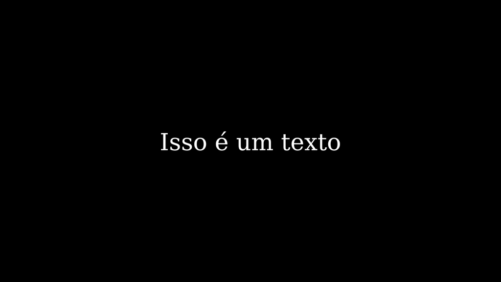

```python
%%manim -s -v WARNING Texto

class Texto(Scene):
  def construct(self):
    texto = Text('Isso é um texto')
    self.add(texto)
```

> Obs: usamos o método `add` para adicionar um objeto gráfico à cena resultando em apenas uma imagem.

Podemos mudar a fonte do texto usando o argumento `font`.

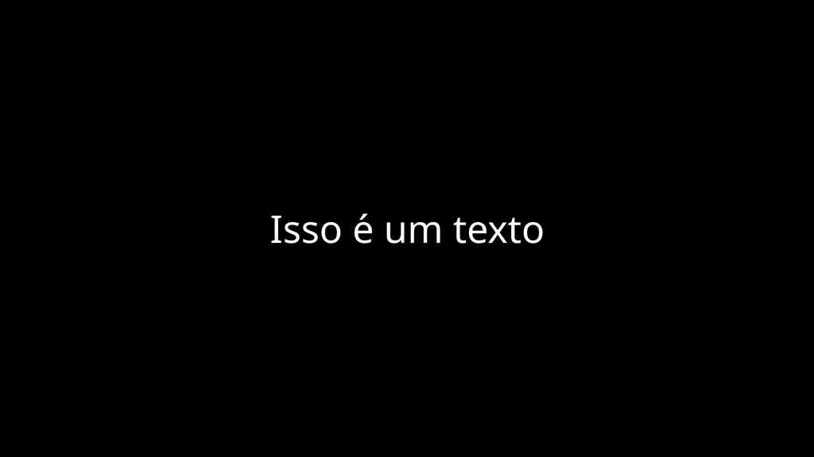

```python
%%manim -s -v WARNING Texto

class Texto(Scene):
  def construct(self):
    texto = Text('Isso é um texto', font='Noto Sans')
    self.add(texto)
```

Para mudar a formatação do texto em normal e itálico, usar o argumento `slant` com os parâmetros `NORMAL` e `ITALIC`.

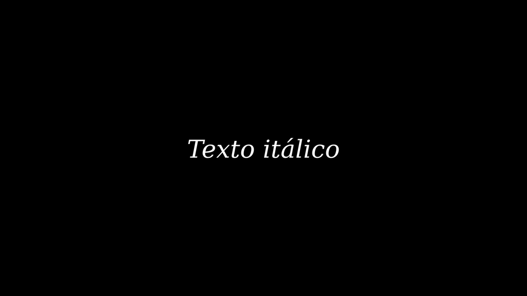

```python
%%manim -s -v WARNING Texto

class Texto(Scene):
  def construct(self):
    texto = Text('Texto itálico', slant=ITALIC)
    self.add(texto)
```

Também é possível mudar a cor com o argumento `color`.

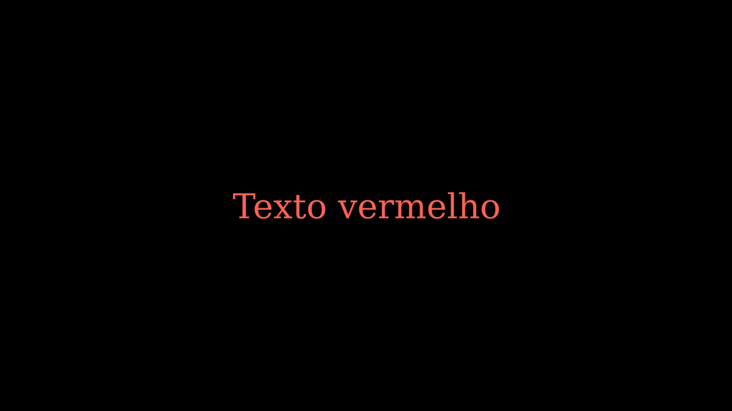

```python
%%manim -s -v WARNING Texto

class Texto(Scene):
  def construct(self):
    texto = Text('Texto vermelho', color=RED)
    self.add(texto)
```

Também podemos mudar a cor do texto com o `MarkupText`. Ela renderiza um texto em formato Markup que é uma linguagem que permite formatar o texto. Para definir um bloco do texto que queremos editar, usamos as tags `<span>` com a propriedade `fgcolor` como no exemplo a seguir.

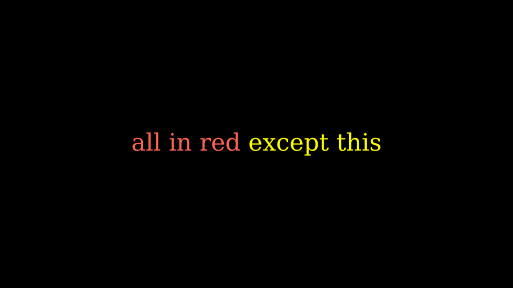

```python
%%manim -s -v WARNING Texto

class Texto(Scene):
    def construct(self):
        text = MarkupText(f'all in red <span fgcolor="{YELLOW}">except this</span>', color=RED)
        self.add(text)
```

Tamém podemos criar gradientes de cores com o argumento `gradient`.

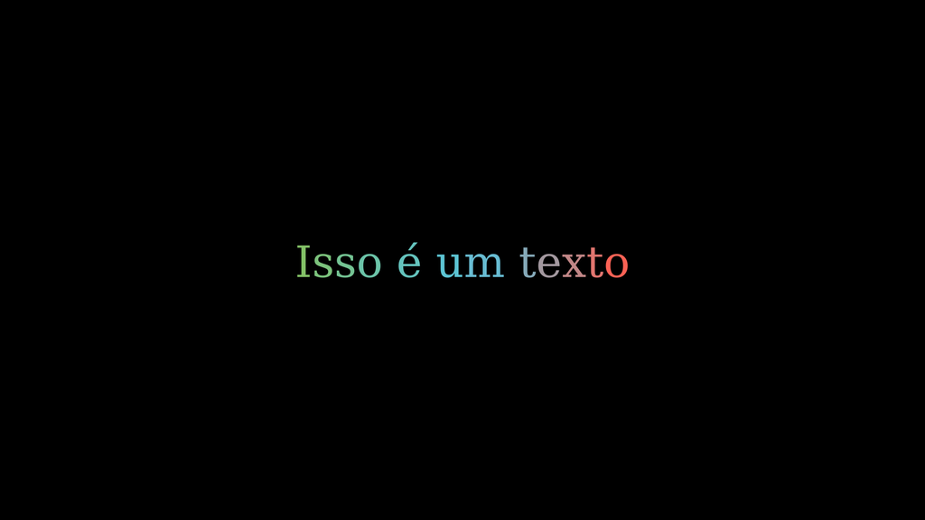

```python
%%manim -s -v WARNING Texto

class Texto(Scene):
    def construct(self):
        text = MarkupText('Isso é um texto', gradient={RED, GREEN, BLUE})
        self.add(text)
```

Agora que vimos como usar textos no Manim, vamos ver como utilizar as fórmulas e expressõers matemáticas. Para isso, usaremos o Latex, uma linguagem de marcação muito usada para escrever artigos científicos e que permite escrever documentos e renderizar expressões matemáticas. Para aprender mais sobre o Latex, consulte o seguinte [material](https://pt.overleaf.com/learn/latex/Learn_LaTeX_in_30_minutes).

Se você não tem muita prática com o Latex, você pode usar o seguinte [site](https://www.codecogs.com/latex/eqneditor.php) para criar as fórmulas matemáticas.

Para renderizar as equações aqui no Google Colab, colocamos a expressão entre $$. Vamos ver algumas expressões que podem ser criadas no Latex.

- mutiplicação - \cdot $\cdot$
- três pontos
- divisão - \div $\div$
- somatório - \sum $\sum$
- limite - \lim*{x \rightarrow a} f(x) $\lim*{x \rightarrow a} f(x)$
- seta direita - \rightarrow $\rightarrow$
- seta esquerda - \leftarrow $\leftarrow$
- menor ou igual - \leq $\leq$
- maior ou igual - \geq $\geq$
- aproximado - \approx $\approx$
- pertence - \in $\in$
- não pertence - \notin $\notin$
- raíz quadrada - \sqrt{x} $\sqrt{x}$
- raíz - \sqrt[n]{x} $\sqrt[n]{x}$
- fração - \frac{a}{b} $\frac{a}{b}$
- intersecção - \cap $\cap$
- união - \cup $\cup$
- vezes - \times $\times$
- pi - \pi $\pi$
- theta - \theta $\theta$
- Quebra de linha - \\
- Equações -

$f(x) = 3 + 2 + 1\\ = 5 + 1 \\ = 6$

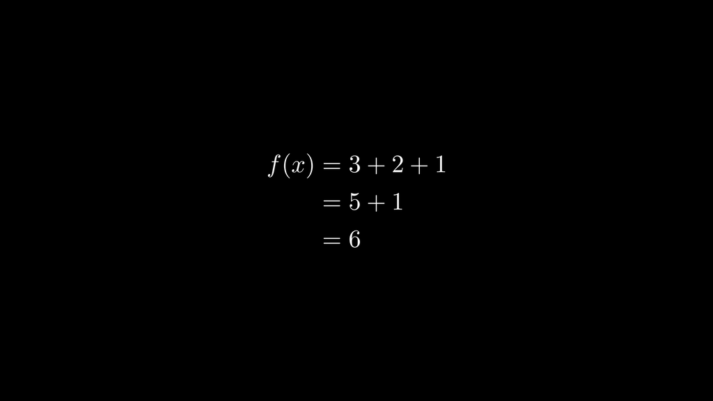

```python
%%manim -s -v WARNING Texto

class Texto(Scene):
    def construct(self):
        text = MathTex(r'f(x) &= 3 + 2 + 1\\ &= 5 + 1 \\ &= 6')
        self.add(text)
```

Também podemos separar um MathTex como uma lista separando os textos por vírgulas.

```python
%%manim -qm -v WARNING Texto

class Texto(Scene):
    def construct(self):
        texto = MathTex(r'\lim_{a \rightarrow 0} \frac{f(x+a) - f(x)}{a} = ', r'\frac{df(x)}{dx}').scale(1.5)
        # Animando a parte do limite
        self.play(Write(texto[0]))
        # Pausa de 1 segundo
        self.wait()
        # Animando a parte da derivada
        self.play(Write(texto[1]))
```

[video not shown]

O Latex também possui o modo texto. Usamos o comando `\text{}` para isso. No `Manim`, podemos usar o `Tex` para isso. Podemos utilizá-lo com listas igual ao `MathTex`.

```python
%%manim -s -v WARNING Texto

class Texto(Scene):
    def construct(self):
        text = Tex('Isso é um Tex', gradient={RED, GREEN, BLUE})
        self.add(text)
```

[output not shown]

Agora, veremos alguns objetos geométricos como retângulos e retas.

> Obs: não abordaremos todos os objetos geométricos. Para mais informações, consulte [documentação](https://docs.manim.community/en/stable/reference/manim.mobject.geometry.html).

Para começar vamos ver o objeto `Square`, ou seja, quadrado. Passamos o tamanho do lado para ele.

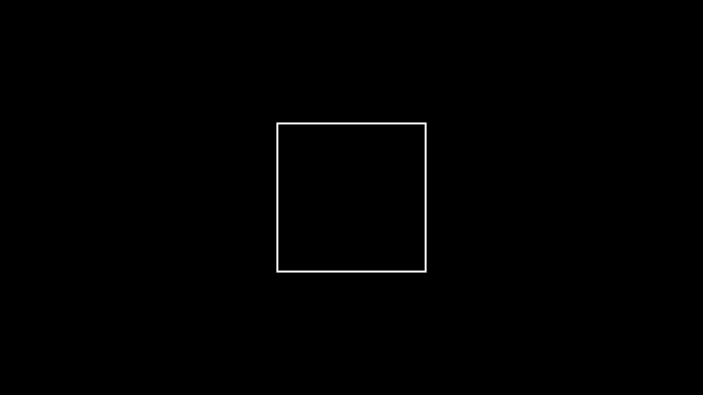

```python
%%manim -s -v WARNING Quadrado

class Quadrado(Scene):
    def construct(self):
        quadrado = Square(side_length=3)
        self.add(quadrado)
```

O `Rectangle` é usado para criar um retângulo. Passamos os tamanhos de seus lados.

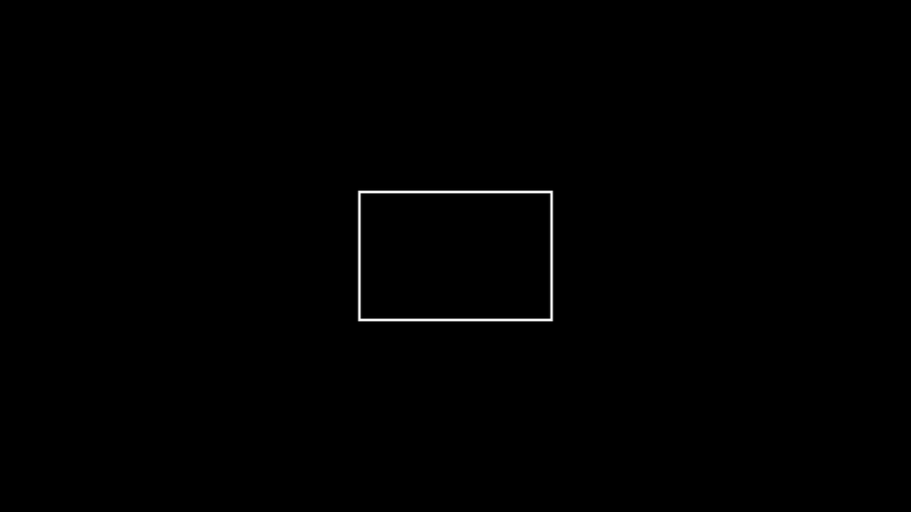

```python
%%manim -s -v WARNING Retangulo

class Retangulo(Scene):
    def construct(self):
      retangulo = Rectangle(height=2, width=3)
      self.add(retangulo)
```

Usamos o `Circle` para criar um círculo. Passamos o seu raio.

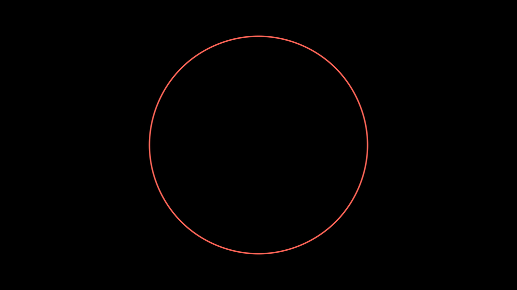

```python
%%manim -s -v WARNING Circulo

class Circulo(Scene):
    def construct(self):
      circulo = Circle(radius=3)
      self.add(circulo)
```

Usamos o `Ellipse` para criar uma elipse. Passamos os valores do semi-eixo maior e menor.

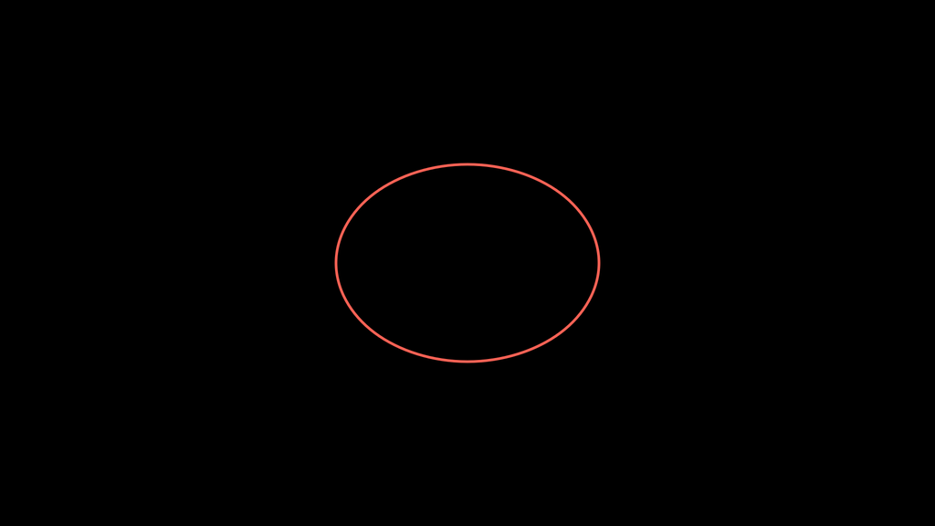

```python
%%manim -s -v WARNING Elipse

class Elipse(Scene):
    def construct(self):
      elipse = Ellipse(height=3, width=4)
      self.add(elipse)
```

Antes de apresentarmos mais objetos, vamos entender como o sistema de coordenadas no Manim funciona.

No Manim, as coordenadas são dadas através de um `numpy.array` de 3 elementos que representam as coordenadas $x$, $y$ e $z$. Mesmo em planos bidimensionais, são passadas as 3 coordenadas. Nesses casos, o terceiro elemento é passado como 0. Por exemplo: `np.array([1, 2, 0])`

Mesmo que o sistema de coordenadas esteja em `numpy.array`, ainda é possível utilizar listas ou tuplas de 3 elementos quando especificarmos a posição dos objetos gráficos na tela. As coordenadas funcionam no sistema $(x, y, z)$, ou seja, $(0, 0, 0)$ é o centro da tela. Se aumentarmos $x$, movemos as coordenadas para direita e, se aumentarmos $y$, movemos as coordenadas para cima.

Para facilitar e não ter que escrever as coordenadas, é possível usar direções (constantes) que especificam essas coordenadas de maneira mais "humana". Existem as constantes:

- `RIGHT`: `np.array([1, 0, 0])`
- `LEFT`: `np.array([-1, 0, 0])`
- `UP`: `np.array([0, 1, 0])`
- `DOWN`: `np.array([0, -1, 0])`

Podemos pensá-las como os vetores na matemática, ou seja, podemos somá-las e multiplicá-las por um número real.

Podemos observar as extremidades da tela no Manim com o seguinte código. Se não entender algo, não se preocupe pois vamos abordar o que não for abordado.

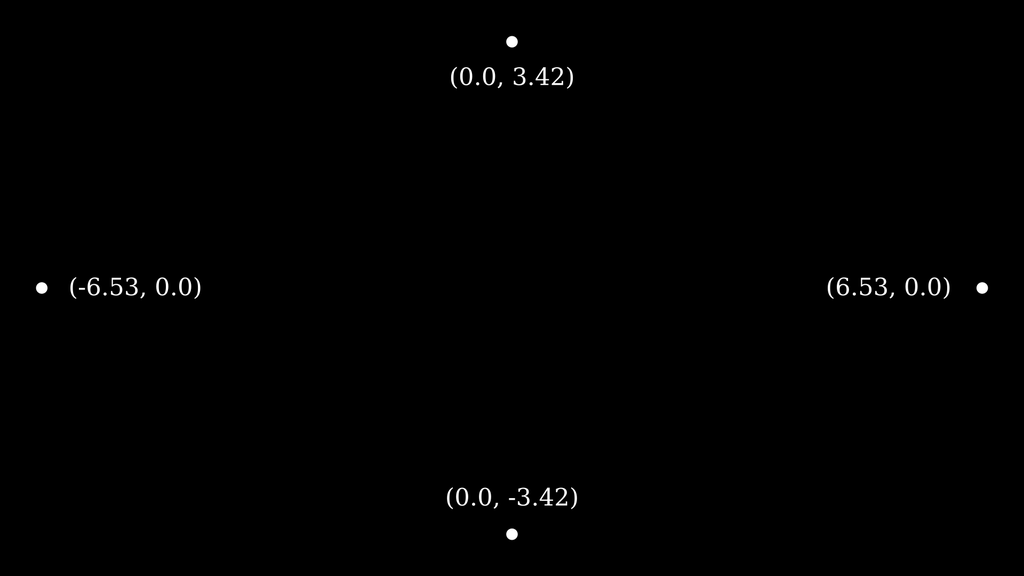

```python
%%manim -s -v WARNING Reta

class Reta(Scene):
    def construct(self):

      def get_coords(mob: Mobject, direction: list):
        text_coords = Text(f'({round(mob.get_x(), 2)}, {round(mob.get_y(), 2)})')
        return text_coords.move_to(mob.get_center() + direction).scale(0.5)

      up = Dot().to_corner(UP)
      right = Dot().to_corner(RIGHT)
      left = Dot().to_corner(LEFT)
      down = Dot().to_corner(DOWN)

      up_label = get_coords(up, 0.5*DOWN)
      right_label = get_coords(right, 1.3*LEFT)
      left_label = get_coords(left, 1.3*RIGHT)
      down_label = get_coords(down, 0.5*UP)

      self.add(up)
      self.add(up_label)
      self.add(right)
      self.add(right_label)
      self.add(left)
      self.add(left_label)
      self.add(down)
      self.add(down_label)
```

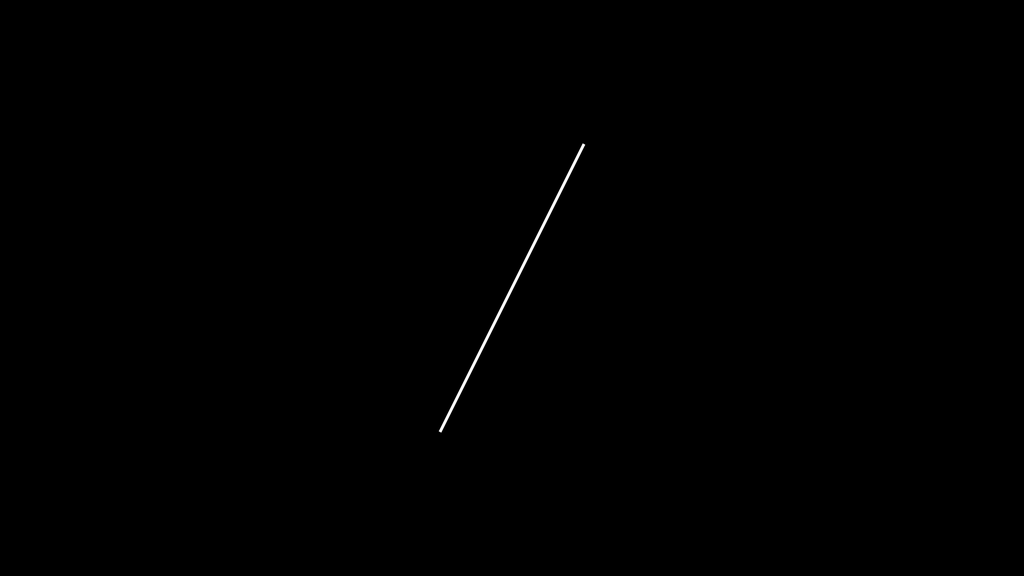

```python
%%manim -s -v WARNING Reta

class Reta(Scene):
    def construct(self):
      reta = Line(start=(-1, -2, 0), end=(1, 2, 0))
      self.add(reta)
```

Usamos o `Arrow` para criar uma seta, informando as coordenadas de início e de fim.

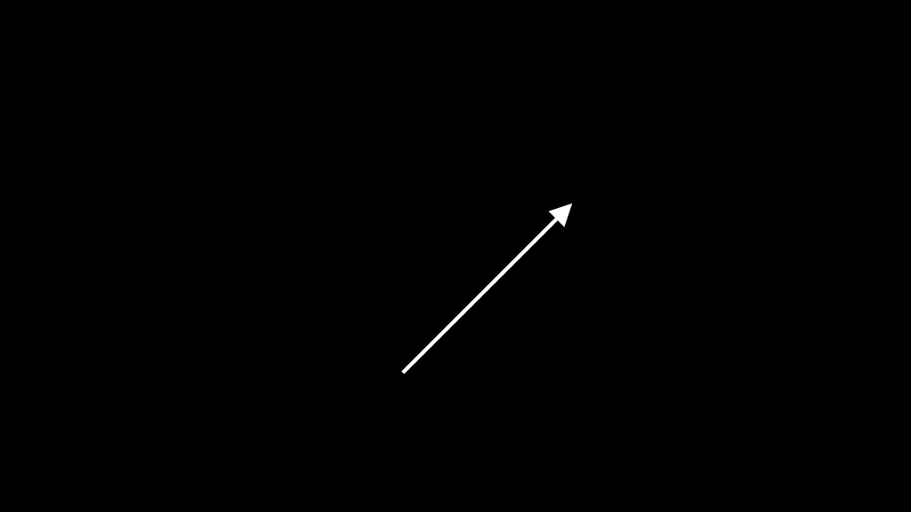

```python
%%manim -s -v WARNING Seta

class Seta(Scene):
    def construct(self):
      seta = Arrow(start=2*DOWN+LEFT, end=UP+2*RIGHT)
      self.add(seta)
```

Usamos o `Dot` para criar um ponto, especificando suas coordenadas.

```python
%%manim -s -v WARNING Ponto

class Ponto(Scene):
    def construct(self):
      ponto = Dot(point=UP*RIGHT)
      self.add(ponto)
```

[output not shown]

Agora que vimos como criar Mobjects, veremos como manipulá-los, ou seja, mudar cor, posição, tamanho, girar, entre outros.

Uma das formas de mover um objeto é com o método `move_to`. Especificamos suas coordenadas e ele move o Mobject.

```python
%%manim -s -v WARNING Mover

class Mover(Scene):
    def construct(self):
      ponto1 = Dot()
      ponto1.move_to(2*UP)

      ponto2 = Dot().move_to(2*DOWN)

      self.add(ponto1)
      self.add(ponto2)
```

[output not shown]

Outra forma de mover objetos é com o `next_to`. Como o próprio nome já diz, "próximo à". Ou seja, especificamos um objeto, em que sentido queremos deixar o objeto e a distância entre os objetos.

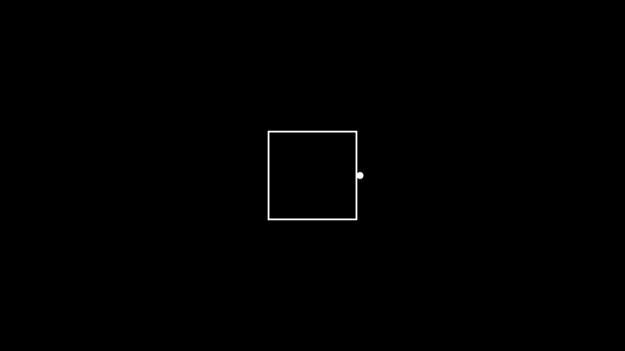

```python
%%manim -s -v WARNING Mover

class Mover(Scene):
    def construct(self):
      quadrado = Square()
      ponto = Dot().next_to(mobject_or_point=quadrado, direction=RIGHT, buff=0)

      self.add(quadrado)
      self.add(ponto)
```

Outra forma de mover objetos é usando o `shift`. Ele move o objeto em relação à sua posição atual. É o método mais simples.

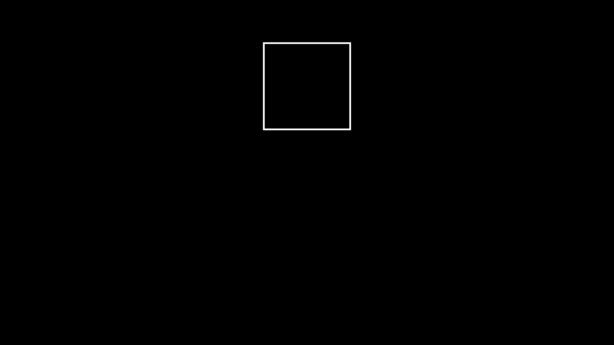

```python
%%manim -s -v WARNING Mover

class Mover(Scene):
    def construct(self):
      quadrado = Square().shift(2*UP)

      self.add(quadrado)
```

A última forma de mover objetos que veremos é o `to_corner`. Ele move o objeto para um dos cantos da tela. Basta passar a posição e ele acha o canto.

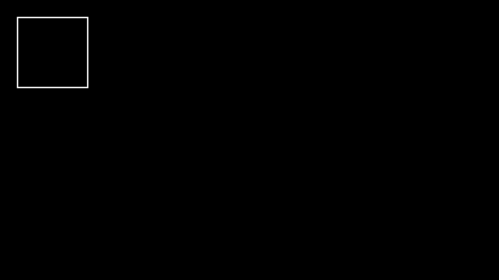

```python
%%manim -s -v WARNING Mover

class Mover(Scene):
    def construct(self):
      quadrado = Square().to_corner(LEFT+UP)

      self.add(quadrado)
```

Para mudar o tamanho dos objetos, usamos o método `scale`. Passamos um número que representa o quanto queremos aumentar o objeto. Se passarmos 2, o objeto aumentará 2 vezes.

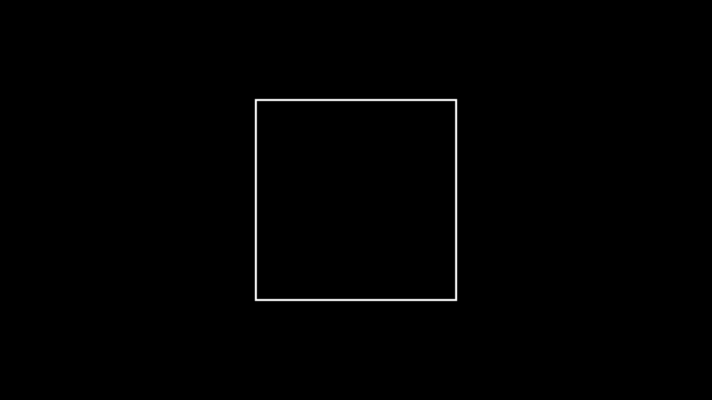

```python
%%manim -s -v WARNING Escala

class Escala(Scene):
    def construct(self):
      quadrado = Square().scale(2)

      self.add(quadrado)
```

Também podemos girar um objeto com o `rotate`. Passamos o ângulo em radianos para o método e ele gira o objeto. Podemos usar o `DEGREES` para converter para graus.

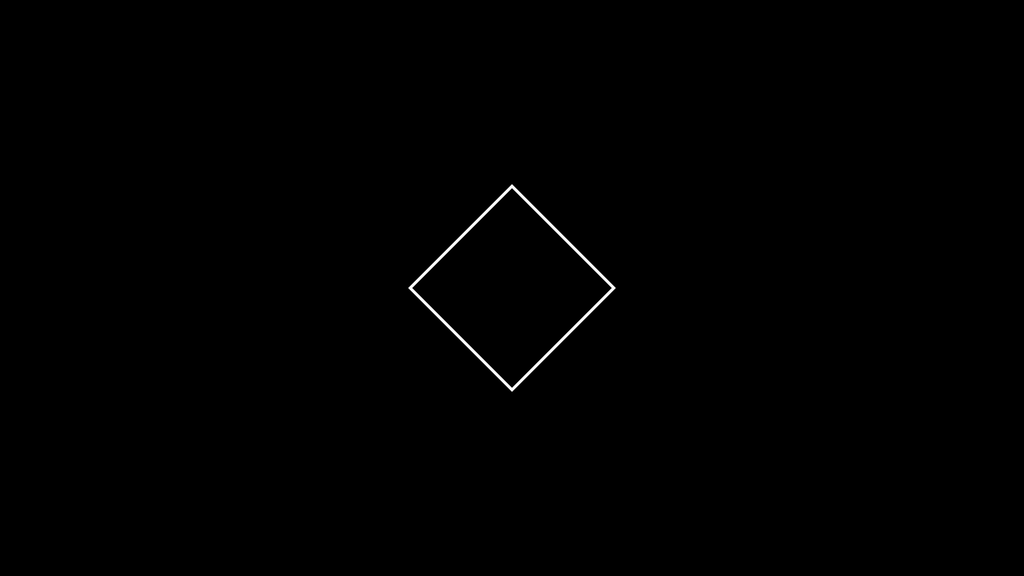

```python
%%manim -s -v WARNING Rotacionar

class Rotacionar(Scene):
    def construct(self):
      quadrado = Square().rotate(45*DEGREES)

      self.add(quadrado)
```

Podemos alterar a cor dos objetos com o `set_color`. O Manim possui constantes com algumas cores pré-definidas. Também podemos especificar cores em hexadecimal.

> Obs: Para mais informações, consultar [documentação](https://docs.manim.community/en/stable/reference/manim.utils.color.Colors.html#manim.utils.color.Colors).

> Obs: Para passar a cor em hexadecimal, usar uma ferramenta para escolher a cor.

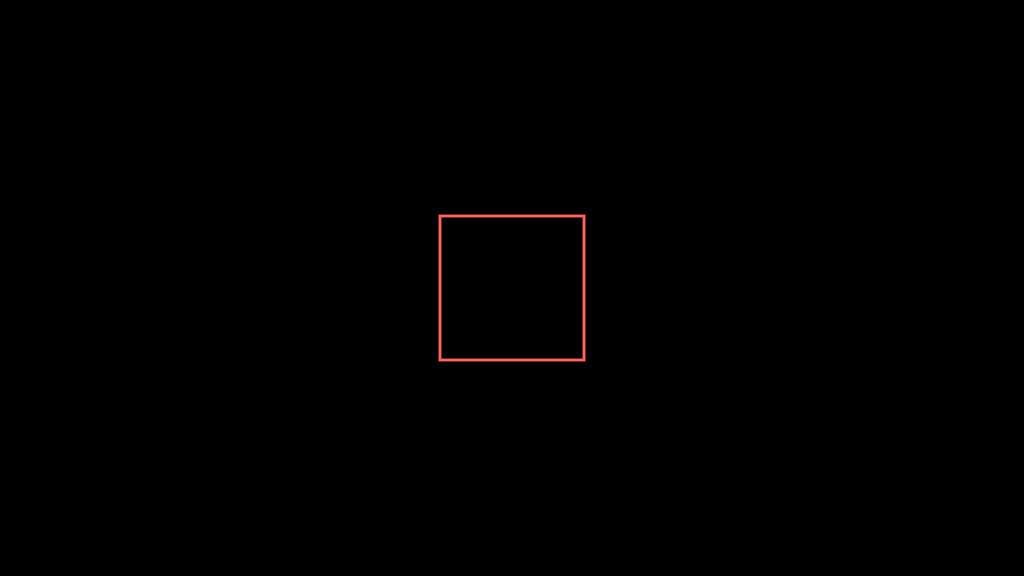

```python
%%manim -s -v WARNING Cor

class Cor(Scene):
    def construct(self):
      quadrado = Square().set_color(RED)

      self.add(quadrado)
```

No Manim, quando alteramos os atributos de um objeto, nem sempre isso se reflete na tela. Para isso, usamos o método `become` que transforma um objeto em outro.

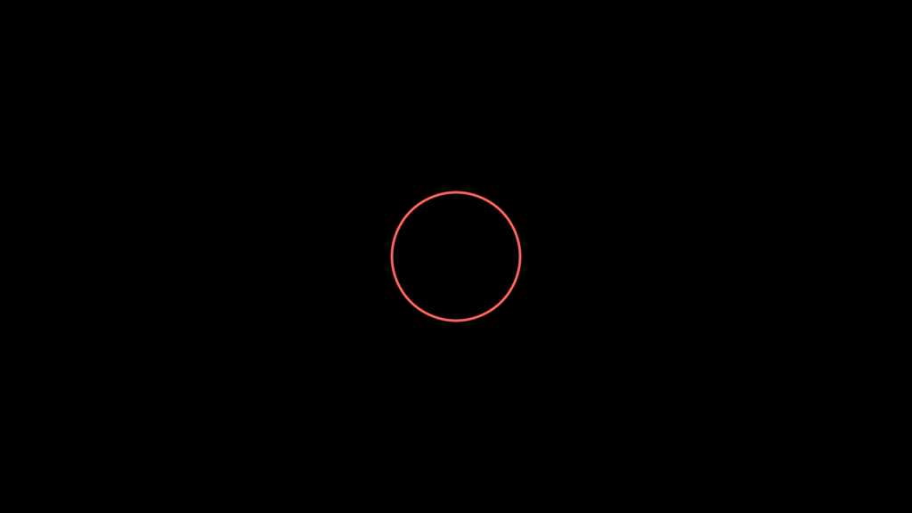

```python
%%manim -s -v WARNING Tornar

class Tornar(Scene):
    def construct(self):
      quadrado = Square()
      quadrado.become(Circle())
      self.add(quadrado)
```

Uma forma de criarmos cópias de objetos é com o método `copy`. Isso não é um método do Manim, mas do próprio Python. Todos os objetos possuem esse método.

[figure not shown]

```python
%%manim -s -v WARNING Copia

class Copia(Scene):
    def construct(self):
      quadrado1 = Square().shift(DOWN)
      quadrado2 = quadrado1.copy().shift(2*UP+2*LEFT)

      self.add(quadrado1)
      self.add(quadrado2)
```

É possível agrupar Mobjects usando listas. Entretanto, há um jeito melhor para fazer isso. Para criar um grupo de Mobjects, usamos o `VGroup`. Nele, colocamos todos os objetos que queremos agrupar. Ele é muito útil quando queremos manipular vários objetos que compõem um todo.

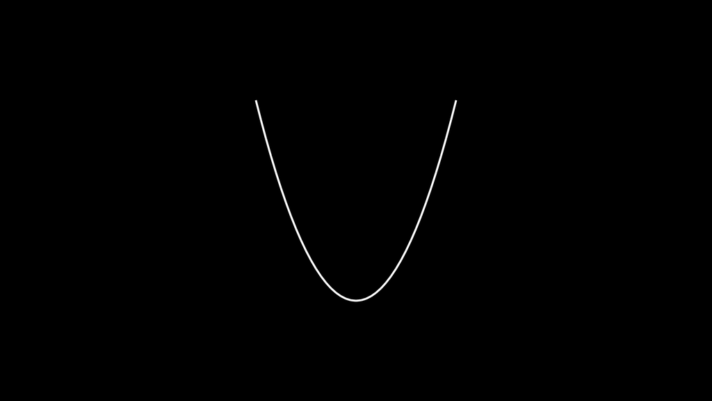

```python
%%manim -s -v WARNING Grupo

class Grupo(Scene):
    def construct(self):
      # Definindo função da parábola
      func = lambda x: x**2 - 2
      # Criando um grupo de linhas que irá repesentar a parábola
      parabola = VGroup(
          # Usando o desempacotamento de listas
          #para passar todas as linhas como parâmetro
          *[
            # Linha que começa em (i, f(i)) e termina em (i+0.1, f(1+0.1))
            Line(
                start=(i, func(i), 0),
                end=(i+0.1, func(i+0.1), 0)
            )
            for i in np.arange(-2, 2, 0.1)
          ]
      )

      self.add(parabola)
```

Agora que vimos vários elementos gráficos, vamos começar com as animações. Como foi visto anteriormente, animamos uma cena utilizando o método `construct`. Dentro dele, chamamos o método `play` e a animação que queremos renderizar. Veremos essas animações nesta seção. Em todas elas, passamos o objeto que queremos animar e a animação faz o resto do trabalho. No `play`, também podemos passar um parâmetro `run_time` que é o tempo que a animação vai durar.

A primeira animação que veremos é o `Write`. Ela anima um objeto com se estivesse escrevendo-o como o próprio nome diz.

```python
%%manim -qm -v WARNING Escrever

class Escrever(Scene):
    def construct(self):
      texto =  Text('Texto escrito').scale(2)
      self.play(Write(texto), run_time=2)
```

[video not shown]

> Obs: É normal esquecer de passar a animação e passar apenas um Mobject pelo `play`. Nesses casos, aparecerá um erro que alertará o usuário que não há animação sendo passada.

O `FadeIn` anima o objeto como se estivesse aparcendo na tela.

```python
%%manim -qm -v WARNING Aparecer

class Aparecer(Scene):
    def construct(self):
      texto =  Text('Texto apareceu').scale(2)
      self.play(FadeIn(texto, run_time=2))
```

[video not shown]

Ao contrário das animações que vimos até agora, o `FadeOut` faz o objeto gráfico desaparecer.

```python
%%manim -qm -v WARNING Desaparecer

class Desaparecer(Scene):
    def construct(self):
      texto =  Text('Texto desapareceu').scale(2)
      self.play(FadeIn(texto), run_time=1)
      self.wait()
      self.play(FadeOut(texto), run_time=2)
```

[video not shown]

Agora, vamos ver animações que pegam objetos e os transformam em outros. O `Transform` e `ReplacementTransform` cumprem esse papel. Passamos o objeto inicial e o final.

```python
%%manim -qm -v WARNING QuadradoParaCirculo

class QuadradoParaCirculo(Scene):
    def construct(self):
      quadrado = Square(side_length=2)
      circulo = Circle(radius=2)

      self.play(Write(quadrado))
      self.play(Transform(quadrado, circulo))
```

[video not shown]

A diferença entre o `Tranform` e o `ReplacementTransform` é que, para manipular os objetos depois da transformação com o:

- `Transform`: o objeto a ser manipulado no final da transformação deve ser o inicial
- `ReplacementTransform`: o objeto a ser manipulado no final da transformação deve ser o final

```python
%%manim -qm -v WARNING QuadradoParaCirculo

class QuadradoParaCirculo(Scene):
    def construct(self):
      quadrado1 = Square(side_length=2)
      circulo1 = Circle(radius=2)

      self.play(Write(quadrado1))
      self.play(Transform(quadrado1, circulo1))

      self.play(FadeOut(quadrado1))

      quadrado2 = Square(side_length=2)
      circulo2 = Circle(radius=2)

      self.play(Write(quadrado2))
      self.play(ReplacementTransform(quadrado2, circulo2))

      self.play(FadeOut(circulo2))
```

[video not shown]

Se não fizermos isso, coisas estranhas acontecerão!

```python
%%manim -qm -v WARNING QuadradoParaCirculo

class QuadradoParaCirculo(Scene):
    def construct(self):
      quadrado1 = Square(side_length=2)
      circulo1 = Circle(radius=2)

      self.play(Write(quadrado1))
      self.play(Transform(quadrado1, circulo1))

      self.play(FadeOut(circulo1))

      quadrado2 = Square(side_length=2)
      circulo2 = Circle(radius=2)

      self.play(Write(quadrado2))
      self.play(ReplacementTransform(quadrado2, circulo2))

      self.play(FadeOut(quadrado2))
```

[video not shown]

A manipulação de objetos, movendo-os ou alterando seus tamanhos, não acontece em forma de animação. Para animar esse tipo de manipulação, é necessário usar o atributo `animate`.

```python
%%manim -qm -v WARNING QuadradoParaCirculo

class QuadradoParaCirculo(Scene):
    def construct(self):
      quadrado = Square(side_length=2)

      self.play(Write(quadrado))
      self.wait()
      self.play(quadrado.animate.move_to(UP))
```

[video not shown]

Em outras versões do Manim como o Manimcairo e o ManimGL, passamos o método e seus parâmetros. Não conseguimos fazer isso aqui pois esse método foi depreciado. Mas podemos demonstrar como fazer isso com o objeto `ApplyMethod`.

```python
%%manim -qm -v WARNING QuadradoParaCirculo

class QuadradoParaCirculo(Scene):
    def construct(self):
      quadrado = Square(side_length=2)

      self.play(Write(quadrado))
      self.wait()
      self.play(ApplyMethod(quadrado.move_to, UP))
```

[video not shown]

Vimos diversas animações até agora, mas ainda existem diversas outras, basta explorá-las. Para mais informações consulte a [documentação](https://docs.manim.community/en/stable/reference_index/animations.html).

Alguns Mobjects que não vimos são os gráficos. Existem alguns objetos que os repressentam que veremos nesta parte.

O primeiro objeto que veremos é o `NumberLine`. Como o próprio nome já diz, ele representa uma linha (reta) de números (reais). Ela possui um construtor com diversos parâmetros, mas os principais são:

- `x_ramge`: lista ou tupla com 3 parâmetros como se fosse o `range` onde o primeiro número é o número inicial, o segundo é o final e o terceiro é número de passos.
- `include_numbers`: exibe os números na reta
- `length`: tamanho da reta
- `include_tip`: exibe uma seta ao final da reta

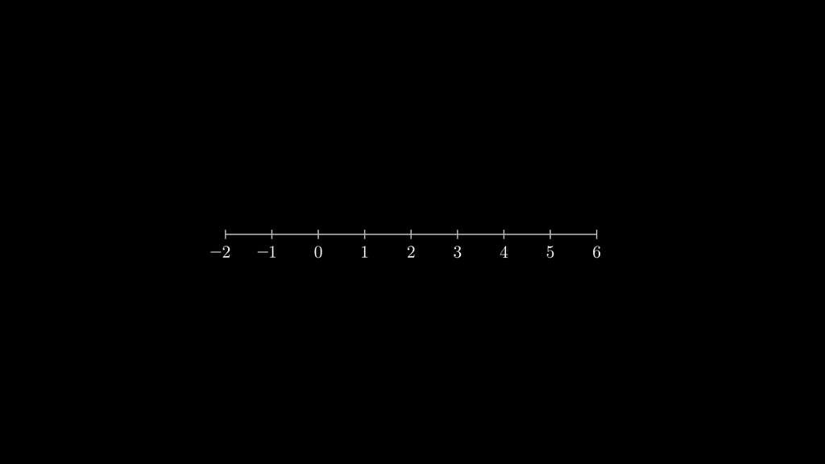

```python
%%manim -s -v WARNING RetaReais

class RetaReais(Scene):
  def construct(self):
    reta_reais = NumberLine(
        x_range=(-2, 6, 1),
        include_numbers=True,
        length=8
    ).scale(0.8)
    self.add(reta_reais)
```

Temos alguns métodos úteis:

- `n2p`: acrônimo para *number to point*. Transforma um número em uma lista de onde o ponto está na reta
- `get_number_mobject`: retorna um `Tex` com o valor passado como parâmetro de acordo com a reta
- `add_labels`: adiciona textos na reta. Útil para adicionar o nome do eixo como $x$ ou $y$

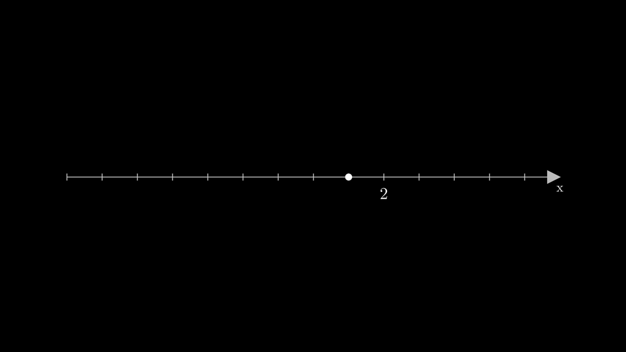

```python
%%manim -s -v WARNING RetaReais

class RetaReais(Scene):
  def construct(self):
    # Criando reta dos reais com uma seta à direita e adicionando label x e escalando em 0.8
    reta_reais = NumberLine(include_tip=True).add_labels({7: 'x'}).scale(0.8)
    # Criando ponto e movendo-o para a posição 1 da reta dos reais
    ponto = Dot().move_to(reta_reais.n2p(1))
    # Criando o número 2 na reta
    numero = reta_reais.get_number_mobject(2)

    self.add(reta_reais, ponto, numero)
```

O `NumberLine` representa um eixo, já a classe `Axes` representa 2 eixos (perpendiculares), ou seja, o plano cartesiano. Possui argumentos parecidos com o do `NuumberLine`, porém, existem os eixos $x$ e $y$.

- `x_range` e `y_range`: funciona como o `range`, porém para os eixos $x$ e $y$
- `x_length` e `y_length`: funciona como o `length`, porém, para os 2 eixos
- `tips`: funciona como o `include_tip`, porém, para ambos os 2 eixos
- `x_axis_config` e `y_axis_config`: pode passar qualquer argumento de `NumberLine` em um dicionário e irá aplicar ao eixo $x$ ou $y$

Não precisamos passar nenhum parâmetro pelo construtor pois todos os seus parâmetros são opcionais.

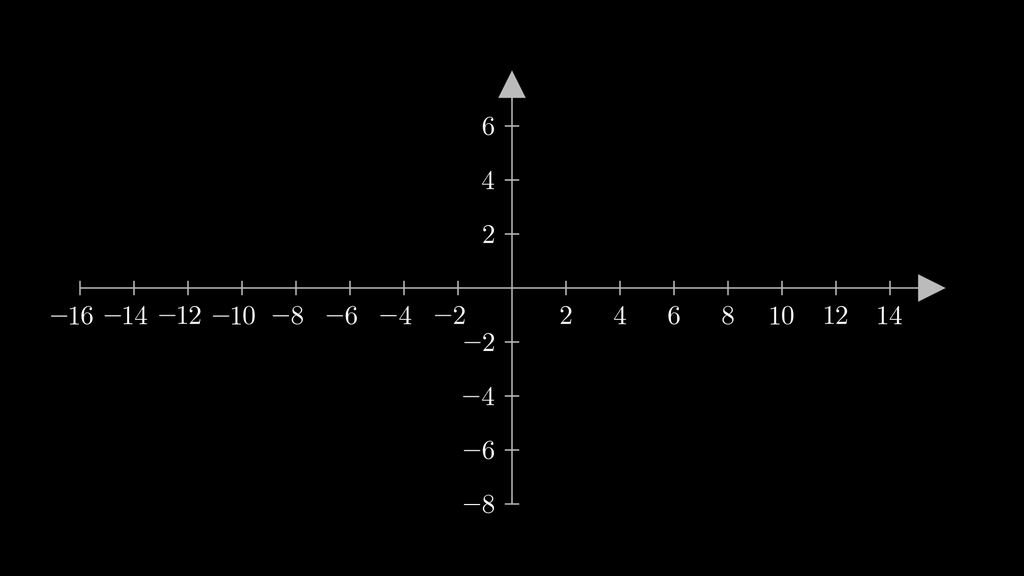

```python
%%manim -s -v WARNING Eixos

class Eixos(Scene):
  def construct(self):
    eixos = Axes(
        tips=True,
        x_range=(-16, 16, 2),
        y_range=(-8, 8, 2),
        x_axis_config={'include_numbers': True},
        y_axis_config={'include_numbers': True}
    )

    self.add(eixos)
```

No código fonte, ele é criado utilizando 2 objetos `NumberLine`, ou seja, podemos pegar cada uma das retas que representam os eixos e usar seus métodos. Para isso, usamos o método `get_axis`. Ele retorna uma lista com os 2 `NumberLine`.

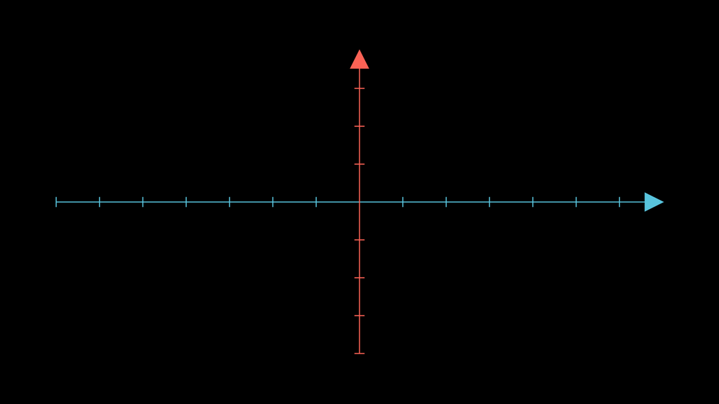

```python
%%manim -s -v WARNING Eixos

class Eixos(Scene):
  def construct(self):
    eixos = Axes()
    eixo_x = eixos.get_axes()[0].set_color(BLUE)
    eixo_y = eixos.get_axes()[1].set_color(RED)

    self.add(eixo_x, eixo_y)
```

Ainda temos alguns métodos interessantes para utilizarmos.

- `c2p`: passa coordenadas $x$ e $y$ e transforma em cordenadas do Manim
- `get_graph`: passa uma função e retorna o gráfico da função
- `get_line_graph`: passa 2 listas, uma com as coordenadas $x$ e outra com as coordenadas $y$ e retorna o gráfico com os pontos conectados por segmentos de retas
- `get_horizontal_line`: passa as coordendas do ponto e retorna a linha horizontal até esse ponto
- `get_vertical_line`: passa as coordenadas do ponto e retorna a linha vertical até esse ponto

[figure not shown]

```python
%%manim -s -v WARNING Eixos

class Eixos(Scene):
  def construct(self):
    # Criando eixos
    eixos = Axes(
        x_axis_config={'include_numbers': True},
        y_axis_config={'include_numbers': True}
    )

    # Criando ponto nas coordeenadas (3, 3) de acordo com os eixos do gráfico
    ponto = Dot().move_to(eixos.c2p(3, 3))
    # Criando linha vertical entra os eixos e o ponto
    v_line = eixos.get_vertical_line(ponto.get_center())
    # Criando linha horizontal entre os eixos e o ponto
    h_line = eixos.get_horizontal_line(ponto.get_center())

    # Declarando função
    f = lambda x: x**2 - 2
    # Declarando pontos x
    x = [i for i in range(-2, 3, 1)]
    # declarando pontos y = f(x)
    y = [f(i) for i in range(-2, 3, 1)]

    # Criando gráfico de linha utilizando as listas x e y
    line_graph = eixos.get_line_graph(x_values=x, y_values=y)
    # Criando o gráfico de f automaticamente
    graph = eixos.get_graph(f, x_range=(-2, 2))

    self.add(eixos, ponto, v_line, h_line, line_graph, graph)
```

O Manim possui diversas animações pré-definidas, porém, é possível criar nossas próprias animações. Para isso, usamos as *update functions*.

As primeiras animações (como as de desenhos e filmes) eram feitas desenhando e gravando diversas imagens (ou mais popularmente conhecidas como *frames*), dando a sensação de movimento. Esse processo é feito até hoje! Entretanto, hoje em dia, existem ferramentas que automatizam uma parte deste processo. Esse tipo de processo também pode ser feito no Manim, utilizando o `wait`.

```python
%%manim -qm -v WARNING Animacao

class Animacao(Scene):
  def construct(self):
    # Criando quadrado
    quadrado = Square()
    # adicionado quadrado à cena
    self.add(quadrado)
    # Adicionando 30 quadros à cena
    for i in range(30):
      # Rotaciona quadrado
      quadrado.rotate(i*DEGREES)
      # Atualiza o quadro a cada 0.1 segundos
      self.wait(0.1)
```

[video not shown]

Em vez de criarmos animações no Manim desse jeito, uma opção melhor é usarmos *updaters*. São funções chamadas uma vez por *frame* renderizado. Criamos uma função chamada *updater* que tem como argumentos um Mobject `mob` e um `dt` que explicaremos depois. Dentro desta função, manipulamos o Mobject da forma que quisermos. Depois de criada, usamos o método `add_updater` e passamos a função *updater* que faz o resto do trabalho. Depois disso, usamos a função `wait` para especificar por quanto tempo queremos que dure a animação. Para parar a animação, usamos o `remove_updaters` ou `clear_updaters`.

```python
%%manim -qm -v WARNING Animacao

class Animacao(Scene):
  def construct(self):
    # Criando variável de controle de rotação do quadrado
    self.offset = 0
    # Função updater usada para rotacionar o quadrado
    def update_quadrado(mob, dt):
      # Chamando método rotate do Mobject
      mob.rotate(DEGREES)
    # Criando quadrado
    quadrado = Square()
    # Adicionando updater ao quadrado
    quadrado.add_updater(update_quadrado)
    # Adicionando quadrado à cena
    self.add(quadrado)
    # Definindo 4 segundos de animação
    self.wait(4)
    # removendo updater do quadrado
    quadrado.remove_updater(update_quadrado)
    self.wait()
```

[video not shown]

Há algumas situações que não podemos atualizar alguma propriedade do objeto. Por exemplo, não podemos mudar os pontos de início e fim do objeto `Line`. Para isso, transformamos o objeto em outro `Line` utilizando o `become` dentro da função *updater*.

```python
%%manim -qm -v WARNING Animacao

class Animacao(Scene):
  def construct(self):
    # Definindo variável de controle para a posição do fim da reta
    self.offset = 0
    # Definindo posição de fim
    inicio = ORIGIN
    # Criando círculo
    circulo = Circle()
    # Criando reta
    linha = Line(start=inicio, end=circulo.point_from_proportion(0))

    def update_linha(mob, dt):
        # atualizando posição do ponto
        self.offset += 0.5*dt
        # Utilizando o become para atualizar a reta
        mob.become(Line(inicio, circulo.point_from_proportion(self.offset % 1)))

    self.add(linha, circulo)
    linha.add_updater(update_linha)
    self.wait(4)
    self.remove_updater(update_linha)
    self.wait()
```

[video not shown]

> Obs: `point_from_proportion` é um método de Mobjects que aceita um número de 0 a 1 e retorna a posição proporcional ao número passado. Se o Mobject for um círculo e passamos 0.5 para o método, ele retornará o ponto do círculo à 180º.

Agora que vimos como utilizar os *updaters*, vamos entender o que os argumentos `mob` e `dt` são. O argumento `mob` é aquele que recebe o objeto que o *updater* está chamando. Por exemplo, se tivermos o seguinte código:

```
ponto = Dot()

def updater(mob, dt):
  # código do updater

ponto.add_updater(updater)
```

O objeto ponto será passado como `mob` para a função *updater*.

Mas e o `dt`? Ao chamar o método `add_updater`, a função passada como parâmetro será chamada a cada frame, ou seja, se o vídeo tiver mais quadros/*frames* por segundo ($N_{\text{fps}}$), a animação será mais rápida. Para que isso não aconteça, usamos o `dt` que possui valor $\displaystyle \frac{1}{N_{\text{fps}}}$. Com isso, se renderizarmos em diferentes $N_{\text{fps}}$, vamos obter o mesmo resultado quanto à velocidade da animação.

Por exemplo, uma animação com $N_{\text{fps}}=15$ fps (*frames* por segundo) (opção `-ql`):

```python
%%manim -ql -v WARNING Animacao

class Animacao(Scene):
  def construct(self):
    self.offset = 0
    inicio = ORIGIN
    circulo = Circle()
    linha = Line(start=inicio, end=circulo.point_from_proportion(0))

    def update_linha(mob, dt):
        self.offset += 0.5*dt
        mob.become(Line(inicio, circulo.point_from_proportion(self.offset % 1)))

    self.add(linha, circulo)
    linha.add_updater(update_linha)
    self.wait(4)
    self.remove_updater(update_linha)
    self.wait()
```

[video not shown]

Agora uma animação com $N_{\text{fps}}=60$ fps (opção `-qh`).

```python
%%manim -qh -v WARNING Animacao

class Animacao(Scene):
  def construct(self):
    self.offset = 0
    inicio = ORIGIN
    circulo = Circle()
    linha = Line(start=inicio, end=circulo.point_from_proportion(0))

    def update_linha(mob, dt):
        self.offset += 0.5*dt
        mob.become(Line(inicio, circulo.point_from_proportion(self.offset % 1)))

    self.add(linha, circulo)
    linha.add_updater(update_linha)
    self.wait(4)
    self.remove_updater(update_linha)
    self.wait()
```

[video not shown]

Agora que vimos como utilizar o Manim com exemplos básicos, vamos ver um pouco como criar animações mais completas. Mas se prepare pois elas também darão muito mais trabalho!

No mundo da programação, programadores possuem a mania de querer começar a codificar antes de pensar no que eles precisam fazer. O mesmo vale aqui no Manim. Estamos escrevendo códigos para criar vídeos. É uma boa ideia planejar o que fazer antes de começar a programar. Para isso, é interessante criar um roteiro para a animação. Não precisa ser algo muito complexo ou bonito, mas que você entenda e que te ajude a criar as animações. É possível utilizar outros softwares para isso como:

- [Notion](https://www.notion.so/),
- [OneNote](https://www.onenote.com/download),
- ou até o bloco de notas
- ou colocar no próprio código
- ou até em uma folha de papel !

Pode ser em qualquer forma, contanto que você entenda e que te ajude.

Como estamos usando código para produzir animações, apenas o bloco de notas não é o suficiente para produzir animações no Manim. É possível, mas nada eficiente. Para isso, existem as IDEs (Ambientes de Desenvolvimento Integrados). Eles são ferramentas que nos auxiliam a criar códigos. De certa forma, o Google Collab é uma IDE, mas com poucos recursos. Alguns dos recursos de IDEs que pdem ser citados são:

- *Auto-complete*: nos dá opção do que podemos digitar no código.
- Documentação: exibe a documentação de funções, classes e métodos ao passar o cursor por cima.
- Refatoração: nos permite trocar nomes de variáveis em vários pontos do código dependendo do contexto, procurar por nomes e trocá-los por outros.
- *Build & Run*: nos permite rodar o código sem ter que digitar pelo terminal.
- Terminal integrado: nos dá acesso à linha de comando sem sair do IDE.

Também podemos usar editores de texto que não possuem todas essas ferramentas, mas é possível instalar plugins que dão acesso a essas ferramentas. Algumas das IDEs e editores de texto são:

- [Pycharm](https://www.jetbrains.com/pt-br/pycharm/download/): IDE com inúmeras ferramentas para desenvolvimento
- [Visual Studio Code](https://code.visualstudio.com/): editor de texto leve que permite instalar extensões que dão ferramentas para desenvolvimento

No Python, é interessante organizarmos as bibliotecas que usamos e não usar simplesmente instalá-las todas globalmente. Para isso, usamos a *virtuale* onde instalamos todas as bibliotecas necessárias.

- Comando para criar uma venv

  ```
  python -m venv <nome da venv>
  ```

- Comando para instalar o manim na venv

  ```
  pip install manim
  ```

A organização em um projeto é muito importante. Organizar arquivos em diferentes pastas, cada uma com arquivos em comum. Ao renderizar coisas no Manim, elas ficam armazenadas dentro da pasta `media`. Damos o nome da nossa animação, por exemplo, `geometria_analitica` e colocamos um arquivo .py e um `textos.txt` onde armazenamos os textos usados na animação. E temos o ambiente virtua visto no último tópico

> Obs: Essa parte de textos é opcional, mas serve para organizarmos o processo de criação da animação.

Desse modo, teremos uma estrutura parecida com a seguinte:

- geometia_analitica
  - anim.py
  - textos.txt
- media
- venv

Com as coisas separadas, o projeto fica mais organizado.

Agora que abordamos a organização do projeto em pastas, vamos abordar a organização do código. Para isso, usaremos os comentários. Como já vimos, existem 2 tipos de comentários, os de uma linha e o de múltiplas linhas. Ns exemplos de códgos anteriores, comentamos cada linha para explicar o que estava acontecendo no código, apenas para fins didáticos, entretanto, essa não é uma forma interessante de usar os comentários. Devemos usá-los para anotar coisas de um modo mais geral. Por exemplo, no código de *updaters*

```python
%%manim -qm -v WARNING Animacao

class Animacao(Scene):
  def construct(self):
    # -------- Dados --------
    self.offset = 0
    inicio = ORIGIN

    # -------- Mobjects --------
    circulo = Circle()
    linha = Line(start=inicio, end=circulo.point_from_proportion(0))

    # -------- Updaters --------
    def update_linha(mob, dt):
      '''
        Acompanha a reta ao redor do círculo
      '''
        self.offset += 0.5*dt
        mob.become(Line(inicio, circulo.point_from_proportion(self.offset % 1)))

    # -------- Animações --------
    self.add(linha, circulo)
    linha.add_updater(update_linha)
    self.wait(4)
    self.remove_updater(update_linha)
    self.wait()
```

Usamos os comentários para separar dados, Mobjects e animações, e para documentar as funções.

Ao criarmos textos no Manim, temos que dar nome a cada um deles. Para simplificar essa tarefa, podemos armazená-los em outro arquivo. É para isso que serve o textos.txt. Nele armazenamos os textos usados nas animações e quando precisarmos mudá-los, basta mudar no arquivo e ele mudará na animação. Podemos usar um código para pegar o conteúdo do arquivo e colocá-lo em uma lista onde estão todos os textos.

Criando o arquivo `textos.txt`:

```python
with open('textos.txt', 'w') as arq:
  arq.write('Arquivo de textos \nTexto 1 \nTexto 2 \nTextos 3')
```

Exemplo de animação com o uso do arquivo:

```python
%%manim -qm -v WARNING Animacao

class Animacao(Scene):
  def construct(self):
    textos = self.config_textos('textos.txt')
    for texto in textos:
      self.play(Write(texto))
      self.play(FadeOut(texto))

  # Função para pear os textos de um arquivo e transformá-los em Text
  def config_textos(self, arq_nome):
    # Abrindo arquivo
    with open(arq_nome, 'r') as arq:
      # Lendo linhas do arquivo e armazenando em lista
      textos = arq.readlines()
      m_textos = []
      # Transformando a lista de texto em lista de Text
      for texto in textos:
        m_textos.append(Text(texto))
      return m_textos
```

[video not shown]

Para a organização do código, é interessante dividir as partes em diferentes funções. Algumas dessas funções contém apenas uma cena estática, mas outras, é possível generalizar essa função. Por exemplo, se tivermos uma função animando um gráfico, podemos generalizar a função que será utilizada no gráfico.

```python
%%manim -qm -v WARNING Animacao

class Animacao(Scene):
  def construct(self):
    self.desenhar_reta(lambda x: x**2)

  # Definindo função que pode pegar qualquer função e criar o gráfico a artir dela
  def desenhar_reta(self, f):
    eixos = Axes()
    grafico = eixos.get_graph(f, (-2, 2))

    self.play(Write(eixos))
    self.play(Write(grafico))
```

[video not shown]

Num código usando o Manim, frequentemente precisamos usar diversas linhas de código com a mesma forma. Por exemplo, um código pode ter diversas linhas com `self.play(Write())`. Em vez de repetir essas linhas ao longo do código principal, podemos simplificar todo o código usando funções `lambda`.

```python
%%manim -qm -v WARNING Animacao

class Animacao(Scene):
  def construct(self):
    w = lambda mob: self.play(Write(mob))

    eixos = Axes()
    grafico = eixos.get_graph(lambda x: x**2)

    w(eixos)
    w(grafico)
```

[video not shown]

Os objetos do Manim são utilizados apenas para serem renderizadas no vídeo. Por exemplo, dados de uma elipse como o semi-eixo menor e o semi-eixo maior não são armazenados nos objetos do Manim. Podemos criá-los e herdar da classe `Ellipse`.

```python
%%manim -qm -v WARNING Animacao

# Classe que armazena objeto gráfico elipse e seus dados
class MinhaElipse(Ellipse):
  def __init__(self, a, b):
    self.a = a
    self.b = b
    # Definindo as propriedades da elipse se a > b
    if self.a > self.b:
      # Chamando construtor da classe pai
      super().__init__(2*self.a, 2*self.b)
      c = np.sqrt(self.a**2 - self.b**2)
      self.f1, self.f2 = (-c, 0, 0), (c, 0, 0)
    else:
      # Chamando construtor da classe pai
      super().__init__(self.b, self.a)
      c = np.sqrt(2*self.b**2 - 2*self.a**2)
      self.f1, self.f2 = (0, -c, 0), (0, c, 0)


class Animacao(Scene):
  def construct(self):
    # Instanciando objeto da classe MinhaElipse
    e = MinhaElipse(3, 2)
    focos = VGroup(Dot(e.f1), Dot(e.f2))
    self.play(Write(e))
    self.play(Write(focos))
```

[video not shown]

Chegamos ao fim deste pequeno manual sobre Manim/Python. Para o fim, deixaremos um exemplo de produção de uma animação. Primeiro, iremos apresentar a ideia da animação, ou seja, o que queremos mostrar com ela. Em seguida, iremos estruturar o projeto mostrando o roteiro com os passos a serem seguidos para se completar a animação e os objetos e os movimentos necessários. Por fim, apresentaremos o código do Manim que produz a animação.

Vamos supor que queremos animar o processo de se calcular o comprimento da diagonal de um quadrado de lado $a$. Um possível roteiro com as etapas da animação está mostrado a seguir. Entre colchetes `[ ]` estão os principais *Mobjects* e animações necessárias em cada etapa.

(1) A animação começaria com um quadrado aparecendo na tela. [`Square`, `FadeIn`]

(2) Depois disso, o valor do lado ($a$) seria mostrado próximo a dois lados consecutivos do quadrado. [`MathTex`,`Write`]

(3) Em seguida, a diagonal do quadrado apareceria na tela com uma cor diferente da do quadrado. [`Line`, `Write`, `set_color`]

(4) Próximo a ela, apareceria então o texto $x=?$. Esse texto vai indicar que queremos determinar o comprimento da diagonal. [`MathTex`, `Write`]

(5) O passo seguinte seria destacar o triângulo formado por dois lados consecutivos do quadrado e a diagonal, indicando que é um triângulo retângulo (mostrando que o ângulo entre os lados é reto). O destaque seria feito desenhando o triângulo com outra cor. [`Polygon`]

(6) Com a informação de que é um triângulo retângulo, seria feita a manipulação algébrica: $x^2 = a^2 + a^2 \rightarrow x^2 = 2a^2 \rightarrow x = \sqrt{2a^2} \rightarrow x = \sqrt{2}a$. [`MathTex`, `TransformMatchingTex`,`ReplacementTransform`]

(7) Após essa manipulação, a expressão $x = \sqrt{2}a$ é movida para a região próxima à diagonal. [`MathTex`, `move_to`]

Uma representação visual desse roteiro é apresentado na imagem a seguir (criada com o OneNote).

[figure not shown]

Definido o roteiro, primeiramente temos que pensar nos objetos que aparecem em mais de um passo. Isso porque vamos dividir os passos em funções no código. Como quase todos os objetos são utilizados por mais de um passo da cena, vamos defini-los todos como globais à cena, ou seja, usar o `self` em todos os objetos gráficos.

Vamos ao código. Primeiramente vamos definir o nome da cena, nomeando-a de `DiagonalQuadrado`. Também vamos declarar os métodos (funções de um objeto) dos passos da animação. Não precisa ser um método para cada passo, mas que tenhamos um certo número que deixe o código organizado. Também declaramos uma função para as figuras geométricas que aparecerão na cena. Com isso, teremos a seguinte estrutura do código:

```
class DiagonalQuadrado(Scene):
    def construct(self):
        # código da função

    def config_global(self):
        # código da função

    def mostrar_quadrado(self):
        # código da função

    def mostrar_triangulos(self):
        # código da função

    def mostrar_manipulacao_algebrica(self):
        # código da função
```

Agruparemos a definição e configuração dos objetos gráficos, textos, equações e funções auxiliares dentro da função `config_global`.

Quadrado:

```
self.quadrado = Square(side_length=tamanho_quadrado)\
  .set_color(cor_quadrado)\
  .move_to(posicao_quadrado)
```

Triângulo:

```
cantos_triangulo = (
  get_lados_quadrado(self.quadrado)[1],
  get_lados_quadrado(self.quadrado)[2],
  get_lados_quadrado(self.quadrado)[3],
)
self.triangulo = Polygon(*cantos_triangulo).set_color(cor_triangulo)
```

Quadrado com um ponto no meio para representar o símbolo do ângulo reto do triângulo retângulo:

```
ponto_angulo_retangulo = get_lados_quadrado(self.quadrado)[2]\
  + 0.5*tamanho_angulo_retangulo*UP\
  + 0.5*tamanho_angulo_retangulo*RIGHT
self.angulo_retangulo = VGroup(
  Square(side_length=tamanho_angulo_retangulo)\
  .move_to(ponto_angulo_retangulo)
  .set_color(cor_angulo_retangulo),
  Dot(ponto_angulo_retangulo).scale(0.15*tamanho_quadrado)
)
```

Diagonal do quadrado:

```
pontos_diagonal = (
  get_lados_quadrado(self.quadrado)[1],
  get_lados_quadrado(self.quadrado)[3]
)

self.diagonal = Line(*pontos_diagonal).set_color(cor_diagonal)
```

Agora as cores, tamanhos e posições dos objetos.

```
cor_quadrado = WHITE
  cor_lados_label = WHITE
  cor_diagonal = RED
  cor_x_label = cor_diagonal
  cor_triangulo = PURPLE
  cor_angulo_retangulo = BLUE

  tamanho_quadrado = 4
  tamanho_angulo_retangulo = tamanho_quadrado/10

  posicao_equacoes = 3*RIGHT
  posicao_quadrado = 2*LEFT
```

Definimos as variáveis de cor e posição para cada objeto para facilitar alterações caso necessário.

Textos e equações.

$a$:

```
self.lados_label = VGroup(
  MathTex('a').next_to(self.quadrado, direction=LEFT, buff=0.5),
  MathTex('a').next_to(self.quadrado, direction=DOWN, buff=0.5)
).set_color(cor_lados_label)
```

$x$:

```
self.x_label = MathTex('x=', '?').next_to(self.quadrado, direction=RIGHT, buff=0.5).set_color(cor_x_label)
```

Equações:

```
equacoes = [
  MathTex('x^2', '=', 'a^2', '+', 'a^2'),
  MathTex('x^2=2x^2'),
  MathTex('x=\sqrt{2a^2}'),
  MathTex('x=', '\sqrt{2}a')
]

self.equacoes = [
  equacao.move_to(posicao_equacoes)
  for equacao in equacoes
]
```

Resultado:

```
self.resultado = MathTex('x=', '\sqrt{2}a')\
  .move_to(self.triangulo.get_center() + 0.5*UP + 0.8*RIGHT)\
  .set_color(cor_x_label)
```

Função auxiliar para obter as coordenadas dos vértices do quadrado:

```
def get_lados_quadrado(quadrado):
  lados_quadrado = [
    quadrado.point_from_proportion(i)
    for i in np.arange(0, 1.25, 0.25)
  ]

  return lados_quadrado
```

Essa função é usada também para obter informações para a construção do triângulo e do quadrado que representa o ângulo reto:

```
def get_lados_quadrado(quadrado):
  lados_quadrado = [
      quadrado.point_from_proportion(i)
      for i in np.arange(0, 1.25, 0.25)
  ]
  return lados_quadrado

 cantos_triangulo = (
    get_lados_quadrado(self.quadrado)[1],
    get_lados_quadrado(self.quadrado)[2],
    get_lados_quadrado(self.quadrado)[3],
)

ponto_angulo_retangulo = get_lados_quadrado(self.quadrado)[2]\
  + 0.5*tamanho_angulo_retangulo*UP\
  + 0.5*tamanho_angulo_retangulo*RIGHT
```

As funções que farão as animações dos objetos ficarão escritas como:

`mostrar_quadrado()`

```
def mostrar_quadrado(self):
  write = lambda *mobs: self.play(*(Write(mob) for mob in mobs))

  write(self.quadrado)
  write(self.lados_label)
  write(self.diagonal, self.x_label)
```

`mostrar_triangulo()`

```
def mostrar_triangulo(self):
  write = lambda *mobs: self.play(*(Write(mob) for mob in mobs))
  fadeout = lambda *mobs: self.play(FadeOut(*mobs))
  play = lambda *anim: self.play(*anim)

  write(self.triangulo)
  fadeout(self.quadrado)
  play(self.x_label.animate.move_to(self.triangulo.get_center() + 0.5*UP + 0.5*RIGHT))
  write(self.angulo_retangulo)
```

`mostrar_manipulacao_algebrica()`

```
def mostrar_manipulacao_algebrica(self):
  wait = lambda t=1: self.wait(t)
  play = lambda *anim, t=1: self.play(*anim, run_time=t)
  fadein = lambda *mobs: self.play(FadeIn(*mobs))

  play(
    ReplacementTransform(self.x_label.copy(), self.equacoes[0][0]),
    ReplacementTransform(self.lados_label[0].copy(), self.equacoes[0][2]),
    ReplacementTransform(self.lados_label[1].copy(), self.equacoes[0][4]),
    t=3
  )

  fadein(self.equacoes[0][1], self.equacoes[0][3])
  wait()
  play(TransformMatchingTex(self.equacoes[0], self.equacoes[1]), t=3)
  wait()
  play(TransformMatchingTex(self.equacoes[1], self.equacoes[2]), t=3)
  wait()
  play(TransformMatchingTex(self.equacoes[2], self.equacoes[3]), t=3)
  wait()

  play(
      TransformMatchingTex(self.x_label, self.resultado),
      ReplacementTransform(self.equacoes[3][1].copy(), self.resultado[1])
  )

  wait()
```

Agrupando tudo isso, teremos um possível código para produzir a animação desejada:

```python
%%manim -qm -v WARNING DiagonalQuadrado

class DiagonalQuadrado(Scene):
    def construct(self):
        self.config_global()
        self.mostrar_quadrado()
        self.mostrar_triangulo()
        self.mostrar_manipulacao_algebrica()
    # função com configurações globais da cena
    def config_global(self):
        # função auxiliar para obter a posição dos vértices do quadrado
        def get_lados_quadrado(quadrado):
            lados_quadrado = [
                quadrado.point_from_proportion(i)
                for i in np.arange(0, 1.25, 0.25)
            ]
            return lados_quadrado

        # definição das cores dos objetos
        cor_quadrado = WHITE
        cor_lados_label = WHITE
        cor_diagonal = RED
        cor_x_label = cor_diagonal
        cor_triangulo = PURPLE
        cor_angulo_retangulo = BLUE

        # definição do tamanho dos objetos
        tamanho_quadrado = 4
        tamanho_angulo_retangulo = tamanho_quadrado/10

        # posições dos objetos
        posicao_equacoes = 3*RIGHT
        posicao_quadrado = 2*LEFT

        # cria o quadrado
        self.quadrado = Square(side_length=tamanho_quadrado)\
            .set_color(cor_quadrado)\
            .move_to(posicao_quadrado)

        self.lados_label = VGroup(
            MathTex('a').next_to(self.quadrado, direction=LEFT, buff=0.5),
            MathTex('a').next_to(self.quadrado, direction=DOWN, buff=0.5)
        ).set_color(cor_lados_label)

        # localiza os pontos da diagonal
        pontos_diagonal = (
            get_lados_quadrado(self.quadrado)[1],
            get_lados_quadrado(self.quadrado)[3]
        )

        # cria segmento de reta que representa a diagonal
        self.diagonal = Line(*pontos_diagonal).set_color(cor_diagonal)
        # texto para representar a diagonal como incógnita
        self.x_label = MathTex('x=', '?').next_to(self.quadrado, direction=RIGHT, buff=0.5).set_color(cor_x_label)

        # obtém os vértices do quadrado com os quais será desenhado o triângulo
        cantos_triangulo = (
            get_lados_quadrado(self.quadrado)[1],
            get_lados_quadrado(self.quadrado)[2],
            get_lados_quadrado(self.quadrado)[3],
        )
        # cria o triângulo
        self.triangulo = Polygon(*cantos_triangulo).set_color(cor_triangulo)

        # determina a posição onde será colocado um ponto para representar o
        # ângulo reto
        ponto_angulo_retangulo = get_lados_quadrado(self.quadrado)[2]\
                + 0.5*tamanho_angulo_retangulo*UP\
                + 0.5*tamanho_angulo_retangulo*RIGHT
        # cria um quadrado com um ponto no centro
        self.angulo_retangulo = VGroup(
            Square(side_length=tamanho_angulo_retangulo)\
            .move_to(ponto_angulo_retangulo)
            .set_color(cor_angulo_retangulo),
            Dot(ponto_angulo_retangulo).scale(0.15*tamanho_quadrado)
        )

        # define as equações a serem usadas
        equacoes = [
            MathTex('x^2', '=', 'a^2', '+', 'a^2'),
            MathTex('x^2=2x^2'),
            MathTex('x=\sqrt{2a^2}'),
            MathTex('x=', '\sqrt{2}a')
        ]

        # cria as equações e coloca-as nas posições corretas
        self.equacoes = [
            equacao.move_to(posicao_equacoes)
            for equacao in equacoes
        ]

        # cria a equação que representa o resultado final
        self.resultado = MathTex('x=', '\sqrt{2}a')\
            .move_to(self.triangulo.get_center() + 0.5*UP + 0.8*RIGHT)\
            .set_color(cor_x_label)

    #####################
    # início da animação
    #####################

    def mostrar_quadrado(self):
        write = lambda *mobs: self.play(*(Write(mob) for mob in mobs))

        # Faz aparecer o quadrado na tela (etapa (1))
        write(self.quadrado)
        # Faz aparecer o nome para o lado do quadrado (etapa (2))
        write(self.lados_label)
        # Faz aparecer a diagonal do quadrado e o valor da diagonal como incógnita
        # (etapa (3) e (4))
        write(self.diagonal, self.x_label)


    def mostrar_triangulo(self):
        write = lambda *mobs: self.play(*(Write(mob) for mob in mobs))
        fadeout = lambda *mobs: self.play(FadeOut(*mobs))
        play = lambda *anim: self.play(*anim)

        # Destaca triângulo e indica que ele é retângulo (etapa (5))
        write(self.triangulo)
        fadeout(self.quadrado)
        play(self.x_label.animate.move_to(self.triangulo.get_center() + 0.5*UP + 0.5*RIGHT))
        write(self.angulo_retangulo)

    def mostrar_manipulacao_algebrica(self):
        wait = lambda t=1: self.wait(t)
        play = lambda *anim, t=1: self.play(*anim, run_time=t)
        fadein = lambda *mobs: self.play(FadeIn(*mobs))

        # Animação das manipulações algébricas
        # etapa (6)
        play(
            ReplacementTransform(self.x_label.copy(), self.equacoes[0][0]),
            ReplacementTransform(self.lados_label[0].copy(), self.equacoes[0][2]),
            ReplacementTransform(self.lados_label[1].copy(), self.equacoes[0][4]),
            t=3
        )

        fadein(self.equacoes[0][1], self.equacoes[0][3])
        wait()
        play(TransformMatchingTex(self.equacoes[0], self.equacoes[1]), t=3)
        wait()
        play(TransformMatchingTex(self.equacoes[1], self.equacoes[2]), t=3)
        wait()
        play(TransformMatchingTex(self.equacoes[2], self.equacoes[3]), t=3)
        wait()

        # etapa (7)
        play(
            TransformMatchingTex(self.x_label, self.resultado),
            ReplacementTransform(self.equacoes[3][1].copy(), self.resultado[1])
        )

        wait()

        #####################
        # fim da animação
        #####################
```

[video not shown]

# O Manim possui uma comunidade muito ativa atualmente que mantém o projeto e sua documentação. Para acessar essa documentação e redes sociais, acesse o seguinte [link](https://www.manim.community/). Nele estão todas as formas de comunicação com a comunidade. Grande parte dos exemplos de animação criados neste manual foram criados consultando essa documentação. Além da documentação oficial, há também outras fontes que podem ser consultadas. Uma delas é o canal de Alexander Vázquez [Theorem of Beethoven](https://www.youtube.com/channel/UCxiWCEdx7aY88bSEUgLOC6A) e os materiais produzidos por ele disponível no [Github](https://github.com/Elteoremadebeethoven).